# Multivariate Results

Kathryn Denning

1/14/2021

```
## [1] "png"
```

# Checking if conditions need collapsed

## Stereotyping outcome

```r
# Number of effect sizes per comparison we coded
k_per_comparison <- meta_data %>%
  dplyr::select(dunb, pt_comparison, outcome_type) %>%
  unique() %>%
  group_by(pt_comparison, outcome_type) %>%
  count() %>% mutate(pt_comparison = dplyr::recode(pt_comparison,
                                `1` = "Self PT vs Day control",
                                `2` = "Self PT vs Other control",
                                `3` = "Self PT vs Objective",
                                `4` = "Self PT vs Suppression",
                                `5` = "Other PT vs Day control",
                                `6` = "Other PT vs Other control",
                                `7` = "Other PT vs Objective",
                                `9` = "Other PT vs Self PT",
                                `10` = "PT US vs Day control",
                                `11` = "PT US vs other control",
                                `12` = "PT US vs Objective",
                                `13` = "PT US vs Suppression"))

# For stereotyping outcome
k_per_comparison %>%
  filter(outcome_type == 1)
```

```
## # A tibble: 12 x 3
## # Groups:   pt_comparison, outcome_type [12]
##    pt_comparison             outcome_type     n
##    <fct>                     <fct>        <int>
##  1 Self PT vs Day control    1               30
##  2 Self PT vs Other control  1               13
##  3 Self PT vs Objective      1               33
##  4 Self PT vs Suppression    1                1
##  5 Other PT vs Day control   1                5
##  6 Other PT vs Other control 1               24
##  7 Other PT vs Objective     1               30
##  8 Other PT vs Self PT       1                9
##  9 PT US vs Day control      1                2
## 10 PT US vs other control    1                9
## 11 PT US vs Objective        1                7
## 12 PT US vs Suppression      1                2
```

Our pre-registered rule was that there must be k = 20 per cell. As this does not apply to every relevant cell, we will need to collapse until we reach this. Also, for the prelims analysis, we will not be adding in perspective taking unspecified (PTUS), but will be adding that to relevant comparisons to see if it affects the analyses for published versions. Also, for all analyses in addition to the meta-analyses specified below, we will conduct moderator analyses with sample size and target information.

For stereotyping, we will do the following:

- Drop any comparison including suppression, as there are not enough even when collapsed (k = 3).
- We will fun analyses using two of the following comparisons to get at different theoretical comparisons:
  - We will collapse across the “Day in the life” and “Other” control conditions. This will allow us to analyze Imagine-self versus Imagine-other perspective taking in comparison to a broad control and the objective comparison condition.
  - We will then collapse across Imagine-self and Imagine-other to examine the if there is difference between the effect of perspective taking instructions when the comparison is the “Day in the life control” versus “Other control” or objective comparison.

## Merging/Overlap outcome

```r
# For overlap/merging outcome
k_per_comparison %>%
  filter(outcome_type == 2)
```

```
## # A tibble: 9 x 3
## # Groups:   pt_comparison, outcome_type [9]
##   pt_comparison             outcome_type     n
##   <fct>                     <fct>        <int>
## 1 Self PT vs Day control    2                5
## 2 Self PT vs Other control  2                5
## 3 Self PT vs Objective      2               13
## 4 Self PT vs Suppression    2                5
## 5 Other PT vs Day control   2                4
## 6 Other PT vs Other control 2                8
## 7 Other PT vs Objective     2               18
## 8 Other PT vs Self PT       2                7
## 9 PT US vs other control    2                4
```

Due to the lower number of studies in this outcome category, we will have to collapse across both Imagine-self and Imagine-other perspective taking instructions as well as “Day in the life” and “Other control” comparisons. As this is the most limiting of the outcomes, we will have to collapse this same way in all outcome categories for the overall meta-analysis when we will include outcome as a predictor.

## Interpersonal feelings outcome

```r
# For interpersonal feelings
k_per_comparison %>%
  filter(outcome_type == 3)
```

```
## # A tibble: 9 x 3
## # Groups:   pt_comparison, outcome_type [9]
##   pt_comparison             outcome_type     n
##   <fct>                     <fct>        <int>
## 1 Self PT vs Day control    3                8
## 2 Self PT vs Other control  3               27
## 3 Self PT vs Objective      3               19
## 4 Other PT vs Other control 3               68
## 5 Other PT vs Objective     3               62
## 6 Other PT vs Self PT       3               17
## 7 PT US vs Day control      3                1
## 8 PT US vs other control    3                4
## 9 PT US vs Objective        3                1
```

We will have to collapse across across “day in the life” and “other” control conditions. As our “Self PT versus Objective” is only one study under our pre-registered limit - and this is a preliminary analysis for a doctoral requirement - we will include that category for this analysis with the expectation that when we include regression coefficients and data from contacted authors, it will be over our limit (spoiler alert: it will). Therefore, for the analysis specifically examining interpersonal feelings outcomes, we will not collapse across Imagine-self and Imagine-other instruction comparisons.

# Overall Multivariate Meta-analysis

## Descriptive info

### Number of papers

```r
meta_overall1 %>%
  mutate(authors = as.factor(authors)) %>%
  dplyr::select(authors) %>%
  unique() %>%
  count()
```

```
## # A tibble: 1 x 1
##       n
##   <int>
## 1    74
```

### Number of studies per paper

```r
meta_overall1 %>%
  dplyr::select(study_num_total) %>%
  unique() %>%
  count()
```

```
## # A tibble: 1 x 1
##       n
##   <int>
## 1   119
```

### Number of unique samples

```r
meta_overall1 %>%
  dplyr::select(sample_number_total) %>%
  unique() %>%
  count()
```

```
## # A tibble: 1 x 1
##       n
##   <int>
## 1   136
```

### Unique effect sizes

```r
meta_overall1 %>%
  dplyr::select(effect_size_num) %>%
  unique() %>%
  count()
```

```
## # A tibble: 1 x 1
##       n
##   <int>
## 1   375
```

### Effect sizes per outcome category

```r
meta_overall1 %>%
  dplyr::select(dunb, outcome_type) %>%
  unique() %>%
  group_by(outcome_type) %>%
  count() %>%
  mutate(outcome_type = dplyr::recode(outcome_type,
                               `1` = "Stereotyping/Bias",
                               `2` = "Overlap/Merging",
                               `3` = "Interpersonal Feelings"))
```

```
## # A tibble: 3 x 2
## # Groups:   outcome_type [3]
##   outcome_type            n
##   <fct>               <int>
## 1 Interpersonal Feels   183
## 2 Overlap                53
## 3 Stereotyping          135
```

### Effect sizes per comparison and outcome category

```r
meta_overall1 %>%
  dplyr::select(dunb, pt_comparison, outcome_type) %>%
  unique() %>%
  group_by(pt_comparison, outcome_type) %>%
  count()
```

```
## # A tibble: 6 x 3
## # Groups:   pt_comparison, outcome_type [6]
##   pt_comparison  outcome_type            n
##   <fct>          <fct>               <int>
## 1 pt_v_objective Interpersonal Feels    81
## 2 pt_v_objective Overlap                31
## 3 pt_v_objective Stereotyping           63
## 4 pt_v_control   Interpersonal Feels   103
## 5 pt_v_control   Overlap                22
## 6 pt_v_control   Stereotyping           72
```

## Model results

**Contrasts:**

```r
contrasts(meta_overall1$outcome_type)
```

```
##                     Overlap Stereotyping
## Interpersonal Feels       0            0
## Overlap                   1            0
## Stereotyping              0            1
```

```r
meta_multi2 <- rma.mv(dunb,
                      var_dunb,
                      mods = ~ pt_comparison*outcome_type,
                      random = list(~ 1 | sample_number_total/outcomes_within_sample_var/conditions_within_sample_var,
                                    ~ 1 | outcome_scale_group), data = meta_overall1)

meta_multi2
```

```
##
## Multivariate Meta-Analysis Model (k = 375; method: REML)
##
## Variance Components:
##
##             estim    sqrt  nlvls  fixed
## sigma^2.1  0.1857  0.4309    136     no
## sigma^2.2  0.1304  0.3611    278     no
## sigma^2.3  0.0186  0.1364    350     no
## sigma^2.4  0.0493  0.2220     15     no
##                                                                                 factor
## sigma^2.1                                                          sample_number_total
## sigma^2.2                               sample_number_total/outcomes_within_sample_var
## sigma^2.3  sample_number_total/outcomes_within_sample_var/conditions_within_sample_var
## sigma^2.4                                                          outcome_scale_group
##
## Test for Residual Heterogeneity:
## QE(df = 369) = 2101.7949, p-val < .0001
##
## Test of Moderators (coefficients 2:6):
## QM(df = 5) = 26.8754, p-val < .0001
##
## Model Results:
##
##                                                     estimate      se     zval
## intrcpt                                               0.5385  0.1207   4.4595
## pt_comparisonpt_v_control                            -0.2476  0.0581  -4.2645
## outcome_typeOverlap                                  -0.1966  0.2080  -0.9448
## outcome_typeStereotyping                             -0.6074  0.1719  -3.5342
## pt_comparisonpt_v_control:outcome_typeOverlap         0.2047  0.1227   1.6681
## pt_comparisonpt_v_control:outcome_typeStereotyping    0.3096  0.1187   2.6085
##                                                       pval    ci.lb    ci.ub
## intrcpt                                             <.0001   0.3018   0.7751
## pt_comparisonpt_v_control                           <.0001  -0.3615  -0.1338
## outcome_typeOverlap                                 0.3447  -0.6043   0.2112
## outcome_typeStereotyping                            0.0004  -0.9443  -0.2706
## pt_comparisonpt_v_control:outcome_typeOverlap       0.0953  -0.0358   0.4453
## pt_comparisonpt_v_control:outcome_typeStereotyping  0.0091   0.0770   0.5422
##
## intrcpt                                             ***
## pt_comparisonpt_v_control                           ***
## outcome_typeOverlap
## outcome_typeStereotyping                            ***
## pt_comparisonpt_v_control:outcome_typeOverlap         .
## pt_comparisonpt_v_control:outcome_typeStereotyping   **
##
## ---
## Signif. codes:  0 '***' 0.001 '**' 0.01 '*' 0.05 '.' 0.1 ' ' 1
```

The intercept is when When pt is compared to the objective condition and interpersonal feels is the outcome. When looking at the main effect, this indicates that - in the interpersonal feeling category - the pt v control condition leads to significantly lower effect sizes the pt vs objective. When comparing pt v objective, there is no difference between the interpersonal feels and overlap conditions, but the stereotyping condition is significantly less than the interpersonal feels condition. The estimates representing the contrasts signify the “difference between the differences” (e.g., how large is the difference between the difference between pt comparison levels and outcome levels being compared in this contrast?). This model demonstrates this difference of differences is significant when comparing the stereotyping outcome and pt v control to the interpersonal feels outcome when pt v objective, but only marginal when comparing pt v control in the overlap outcome to the same reference group.

We then ran pairwise comparisons to know the following differences:

- pt_v_control:overlap vs pt_v_control_stereotyping

```r
anova(meta_multi2, btt=5:6)
```

```
##
## Test of Moderators (coefficients 5:6):
## QM(df = 2) = 8.0175, p-val = 0.0182
```

The two contrasts are significantly different.

The interactions in the multivariate overall model tells us there are statistical differences between outcome context and pt condition, but does not tell us the effect sizes per cell (each outcome and pt condition) and if they differ from 0. These were obtained using emmeans.

## Marginal main effects

```r
qdrq1 <- qdrg(object = meta_multi2, data = meta_overall1)

emmeans_multi <- summary(emmeans(qdrq1, "pt_comparison","outcome_type"))
emmeans_multi
```

```
## outcome_type = Interpersonal Feels:
##  pt_comparison    emmean    SE  df asymp.LCL asymp.UCL
##  pt_v_objective  0.53848 0.121 Inf   0.30182     0.775
##  pt_v_control    0.29084 0.118 Inf   0.05953     0.522
##
## outcome_type = Overlap:
##  pt_comparison    emmean    SE  df asymp.LCL asymp.UCL
##  pt_v_objective  0.34192 0.177 Inf  -0.00471     0.689
##  pt_v_control    0.29902 0.179 Inf  -0.05161     0.650
##
## outcome_type = Stereotyping:
##  pt_comparison    emmean    SE  df asymp.LCL asymp.UCL
##  pt_v_objective -0.06895 0.130 Inf  -0.32319     0.185
##  pt_v_control   -0.00702 0.127 Inf  -0.25536     0.241
##
## Confidence level used: 0.95
```

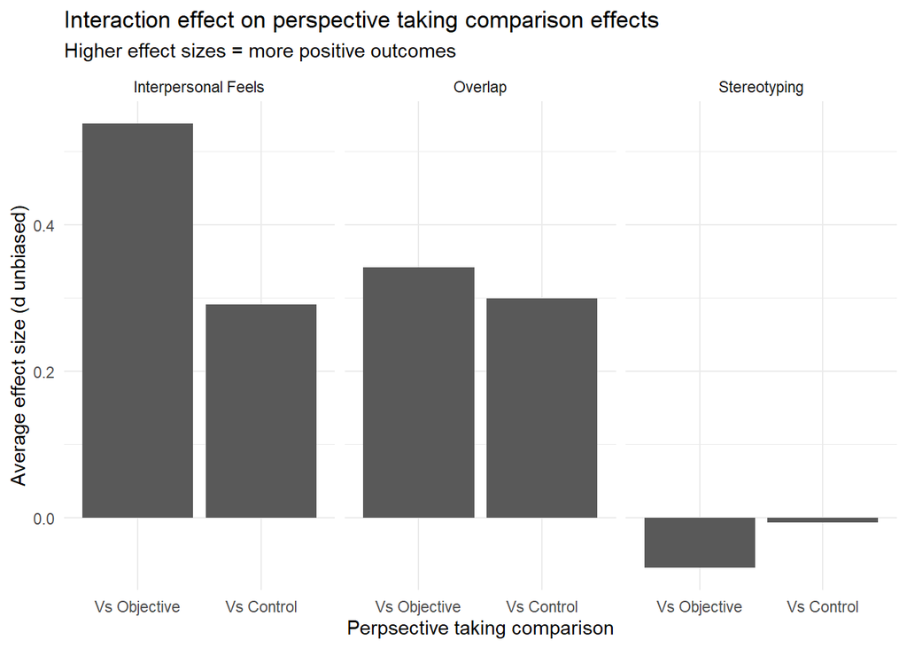

```r
emmeans_multi %>% ggplot(aes(x = pt_comparison, y = emmean)) +
  facet_grid(cols = vars(outcome_type)) +
  geom_col() +
  theme_minimal() +
  labs(title = "Interaction effect on perspective taking comparison effects",
       subtitle = "Higher effect sizes = more positive outcomes",
       x = "Perpsective taking comparison",
       y = "Average effect size (d unbiased)") +
  scale_x_discrete(labels = c('Vs Objective','Vs Control'))
```

The interpersonal feelings outcome results are consistent with McAuliffe’s findings for empathy/empathic concern (they found .68 for Imagine-other and .56 for Imagine-self vs objective, and we are collapsed across here and with other effects to a .54). However, they found a lower average effect for Imagine-other vs no-instructions (.08) than our comparison versus the control (.29), but again, we have more results included. We also obtained our results in the interactive MLM model, not individual meta-analysis models as McAuliffe et al did. MLM models employ shrinkage on the estimates that would not occur when subsetting data down to the individual comparisons, which also accounts for differences between our results and McAuliffe results. This also allows us to retain a larger k.

For the categories other than Interpersonal Feels, none of the other comparisons are statistically different from 0. Because of the significant heterogeneity that is moderated in our overall model, we are going to skip other moderators at the overall model level to explore models within each outcome more deeply. Clearly, at this higher-order level, there is too much variation between the studies for them to be compared as the same thing.

### I2 overall

```r
get_I2_overall(meta_overall1, meta_multi2)
```

```
## [1] 91.12934
```

Overall heterogeneity is very high. 91.13% of the variance can be explained due to differences in the studies not explained by our predictors.

### I2 for levels of variance

*Left value corresponds to top sigma in Variance components output in model results (Sample_number_total). Right-most value corresponds to bottom sigma (Outcome_scale group).*

```r
get_I2_var_levels(meta_overall1, meta_multi2)
```

```
## [1] 44.07 30.95  4.41 11.70
```

Most of this heterogeneity is explained by between-study variance, followed by between-outcome (within-study) variance.

# Stereotyping

## Unique effect sizes

```r
meta_stereo1 %>%
  count()
```

```
## # A tibble: 1 x 1
##       n
##   <int>
## 1   138
```

## Imagine-self vs imagine-other Model

**Contrasts:**

```r
contrasts(meta_stereo1$pt_comparison)
```

```
##                   self_v_control other_v_objective other_v_control
## self_v_objective               0                 0               0
## self_v_control                 1                 0               0
## other_v_objective              0                 1               0
## other_v_control                0                 0               1
```

```r
stereo_meta1 <- rma.mv(dunb,
                      var_dunb,
                      mods = ~ pt_comparison,
                      random = list(~ 1 | sample_number_total/outcomes_within_sample_var/conditions_within_sample_var,
                                    ~ 1 | outcome_scale_group), data = meta_stereo1)

stereo_meta1
```

```
##
## Multivariate Meta-Analysis Model (k = 138; method: REML)
##
## Variance Components:
##
##             estim    sqrt  nlvls  fixed
## sigma^2.1  0.3255  0.5706     61     no
## sigma^2.2  0.0331  0.1820    112     no
## sigma^2.3  0.0798  0.2825    125     no
## sigma^2.4  0.0254  0.1595      6     no
##                                                                                 factor
## sigma^2.1                                                          sample_number_total
## sigma^2.2                               sample_number_total/outcomes_within_sample_var
## sigma^2.3  sample_number_total/outcomes_within_sample_var/conditions_within_sample_var
## sigma^2.4                                                          outcome_scale_group
##
## Test for Residual Heterogeneity:
## QE(df = 134) = 790.6372, p-val < .0001
##
## Test of Moderators (coefficients 2:4):
## QM(df = 3) = 0.5906, p-val = 0.8986
##
## Model Results:
##
##                                 estimate      se     zval    pval    ci.lb
## intrcpt                           0.0842  0.1719   0.4899  0.6242  -0.2527
## pt_comparisonself_v_control      -0.0852  0.2131  -0.3998  0.6893  -0.5028
## pt_comparisonother_v_objective    0.0210  0.1817   0.1154  0.9081  -0.3352
## pt_comparisonother_v_control     -0.1077  0.2056  -0.5240  0.6003  -0.5107
##                                  ci.ub
## intrcpt                         0.4210
## pt_comparisonself_v_control     0.3324
## pt_comparisonother_v_objective  0.3771
## pt_comparisonother_v_control    0.2952
##
## ---
## Signif. codes:  0 '***' 0.001 '**' 0.01 '*' 0.05 '.' 0.1 ' ' 1
```

The intercept is not significantly different from zero, nor do any effects differ from it.

### Marginal main effects

```r
qdrq_stereo1 <- qdrg(object = stereo_meta1, data = meta_stereo1)

emmeans_stereo1 <- summary(emmeans(qdrq_stereo1, "pt_comparison"))
emmeans_stereo1
```

```
##  pt_comparison        emmean    SE  df asymp.LCL asymp.UCL
##  self_v_objective   0.084187 0.172 Inf    -0.253     0.421
##  self_v_control    -0.000995 0.160 Inf    -0.315     0.313
##  other_v_objective  0.105161 0.152 Inf    -0.192     0.403
##  other_v_control   -0.023543 0.155 Inf    -0.327     0.280
##
## Confidence level used: 0.95
```

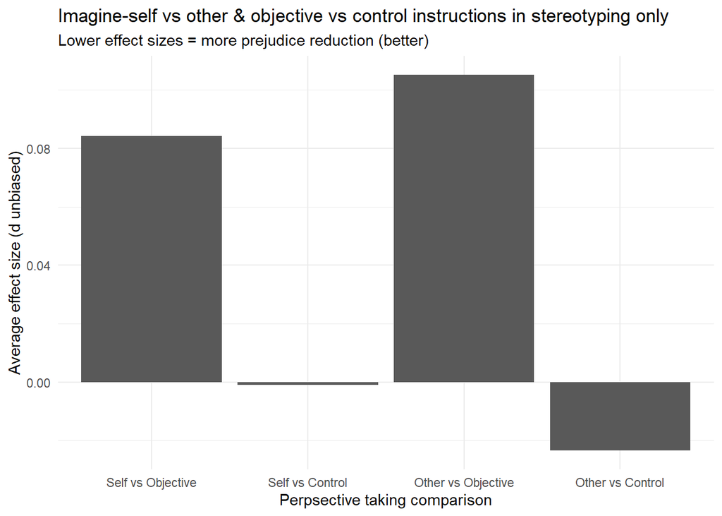

```r
emmeans_stereo1 %>% ggplot(aes(x = pt_comparison, y = emmean)) +
  geom_col() +
  theme_minimal() +
  labs(title = "Imagine-self vs other & objective vs control instructions in stereotyping only",
       subtitle = "Lower effect sizes = more prejudice reduction (better)",
       x = "Perpsective taking comparison",
       y = "Average effect size (d unbiased)") +
  scale_x_discrete(labels = c('Self vs Objective','Self vs Control',
                              'Other vs Objective', 'Other vs Control'))
```

None of the marginal main effects differ from zero. There is an interesting pattern in that self or other vs objective lead to higher effect sizes (less stereotype prejudice reduction). However, with nothing differing from zero, this does not mean anything statistically.

### I2 overall

```r
get_I2_overall(meta_stereo1, stereo_meta1)
```

```
## [1] 91.35313
```

Again, very high.

### I2 for levels of variance

*Left value corresponds to top sigma in Variance components output in model results (Sample_number_total). Right-most value corresponds to bottom sigma (Outcome_scale group).*

```r
get_I2_var_levels(meta_stereo1, stereo_meta1)
```

```
## [1] 64.11  6.52 15.71  5.01
```

Most of the heterogeneity is explained by between-studies variance, with about 16% also explained by between-conditions (within-study) variance. This differed from the heterogeneity pattern found in the overall interaction model.

## Moderators for imagine self vs other model

### Scales of measurement

```r
meta_stereo1 %>%
  group_by(pt_comparison, outcome_scale_group) %>%
  count() %>%
  filter(n <2)
```

```
## # A tibble: 2 x 3
## # Groups:   pt_comparison, outcome_scale_group [2]
##   pt_comparison    outcome_scale_group     n
##   <fct>            <fct>               <int>
## 1 self_v_objective 1                       1
## 2 self_v_control   1                       1
```

```r
#getting rid of cells with only 1
meta_stereo1_mod1_dat <- meta_stereo1 %>%
  filter(!c(pt_comparison == "self_v_objective" & outcome_scale_group == "1" |
           pt_comparison == "self_v_control" & outcome_scale_group == "1"))

stereo_meta1_mod1 <- rma.mv(dunb,
                      var_dunb,
                      mods = ~ pt_comparison*outcome_scale_group,
                      random = list(~ 1 | sample_number_total/outcomes_within_sample_var/conditions_within_sample_var), data = meta_stereo1_mod1_dat)

stereo_meta1_mod1
```

```
##
## Multivariate Meta-Analysis Model (k = 136; method: REML)
##
## Variance Components:
##
##             estim    sqrt  nlvls  fixed
## sigma^2.1  0.2448  0.4948     60     no
## sigma^2.2  0.0124  0.1114    111     no
## sigma^2.3  0.0917  0.3029    123     no
##                                                                                 factor
## sigma^2.1                                                          sample_number_total
## sigma^2.2                               sample_number_total/outcomes_within_sample_var
## sigma^2.3  sample_number_total/outcomes_within_sample_var/conditions_within_sample_var
##
## Test for Residual Heterogeneity:
## QE(df = 117) = 608.0280, p-val < .0001
##
## Test of Moderators (coefficients 2:19):
## QM(df = 18) = 16.8764, p-val = 0.5316
##
## Model Results:
##
##                                                      estimate      se     zval
## intrcpt                                                0.2934  0.3863   0.7596
## pt_comparisonself_v_control                            0.1317  0.3112   0.4232
## pt_comparisonother_v_objective                        -0.3600  0.6183  -0.5822
## pt_comparisonother_v_control                          -0.1049  0.2841  -0.3694
## outcome_scale_group2                                  -0.0524  0.4535  -0.1155
## outcome_scale_group3                                  -0.3891  0.4697  -0.8285
## outcome_scale_group4                                  -0.2668  0.4365  -0.6112
## outcome_scale_group5                                   0.2625  0.4375   0.6001
## outcome_scale_group6                                  -0.2006  0.3080  -0.6514
## pt_comparisonself_v_control:outcome_scale_group2      -0.7994  0.5393  -1.4823
## pt_comparisonother_v_objective:outcome_scale_group2    0.4257  0.7353   0.5790
## pt_comparisonother_v_control:outcome_scale_group2     -0.1699  0.3981  -0.4267
## pt_comparisonself_v_control:outcome_scale_group3      -0.0744  0.4487  -0.1658
## pt_comparisonother_v_objective:outcome_scale_group3    0.1978  0.7609   0.2600
## pt_comparisonself_v_control:outcome_scale_group4      -0.0960  0.3869  -0.2481
## pt_comparisonother_v_objective:outcome_scale_group4    0.1900  0.6830   0.2781
## pt_comparisonother_v_control:outcome_scale_group4      0.0476  0.3670   0.1298
```

[output cut: 10 more lines]

```
## outcome_scale_group5                                 0.5484  -0.5949  1.1200
## outcome_scale_group6                                 0.5148  -0.8043  0.4030
## pt_comparisonself_v_control:outcome_scale_group2     0.1382  -1.8563  0.2576
## pt_comparisonother_v_objective:outcome_scale_group2  0.5626  -1.0155  1.8670
## pt_comparisonother_v_control:outcome_scale_group2    0.6696  -0.9502  0.6104
## pt_comparisonself_v_control:outcome_scale_group3     0.8683  -0.9538  0.8050
## pt_comparisonother_v_objective:outcome_scale_group3  0.7949  -1.2935  1.6892
## pt_comparisonself_v_control:outcome_scale_group4     0.8041  -0.8542  0.6623
## pt_comparisonother_v_objective:outcome_scale_group4  0.7809  -1.1487  1.5286
## pt_comparisonother_v_control:outcome_scale_group4    0.8967  -0.6716  0.7669
## pt_comparisonself_v_control:outcome_scale_group5     0.9582  -0.8425  0.8888
## pt_comparisonother_v_objective:outcome_scale_group6  0.3774  -0.6497  1.7145
##
## ---
## Signif. codes:  0 '***' 0.001 '**' 0.01 '*' 0.05 '.' 0.1 ' ' 1
```

I dropped cells with only 1 study and rma.mv dropped cells with 0. Nothing is significant from one another, and the intercept is not significantly different from 0. Any model with redudancies (0’s in cells) cannot be modeled using emmeans to get marginal means.

#### I2 overall

```r
get_I2_overall(meta_stereo1_mod1_dat, stereo_meta1_mod1)
```

```
## [1] 88.94036
```

Still very high, but slightly lower than without the moderater.

#### I2 for levels of variance

*Left value corresponds to top sigma in Variance components output in model results (Sample_number_total). Right-most value corresponds to bottom sigma (Outcome_scale group).*

```r
get_I2_var_levels(meta_stereo1_mod1_dat, stereo_meta1_mod1)
```

```
## [1] 62.40  3.16 23.38
```

Without the crossed variance structure (because it is a moderator), more of that variance shifted to the between-conditions level. Most of the variance is still represented by the between-studies level.

### Target moderator - information amount

```r
stereo_meta1_mod2 <- rma.mv(dunb,
                      var_dunb,
                      mods = ~ pt_comparison*target_information,
                      random = list(~ 1 | sample_number_total/outcomes_within_sample_var/conditions_within_sample_var,
                                    ~ 1 | outcome_scale_group), data = meta_stereo1)

stereo_meta1_mod2
```

```
##
## Multivariate Meta-Analysis Model (k = 138; method: REML)
##
## Variance Components:
##
##             estim    sqrt  nlvls  fixed
## sigma^2.1  0.3945  0.6281     61     no
## sigma^2.2  0.0750  0.2738    112     no
## sigma^2.3  0.0380  0.1949    125     no
## sigma^2.4  0.0195  0.1395      6     no
##                                                                                 factor
## sigma^2.1                                                          sample_number_total
## sigma^2.2                               sample_number_total/outcomes_within_sample_var
## sigma^2.3  sample_number_total/outcomes_within_sample_var/conditions_within_sample_var
## sigma^2.4                                                          outcome_scale_group
##
## Test for Residual Heterogeneity:
## QE(df = 126) = 759.2016, p-val < .0001
##
## Test of Moderators (coefficients 2:12):
## QM(df = 11) = 6.5617, p-val = 0.8334
##
## Model Results:
##
##                                                     estimate      se     zval
## intrcpt                                              -0.0587  0.4005  -0.1465
## pt_comparisonself_v_control                          -0.1541  0.4817  -0.3199
## pt_comparisonother_v_objective                        0.0493  0.4530   0.1088
## pt_comparisonother_v_control                          0.1574  0.4619   0.3407
## target_information2                                   0.2213  0.4696   0.4713
## target_information3                                   0.1882  0.4907   0.3836
## pt_comparisonself_v_control:target_information2      -0.2341  0.5873  -0.3986
## pt_comparisonother_v_objective:target_information2   -0.0243  0.5600  -0.0434
## pt_comparisonother_v_control:target_information2     -0.7188  0.5763  -1.2472
## pt_comparisonself_v_control:target_information3       0.2991  0.6922   0.4321
## pt_comparisonother_v_objective:target_information3   -0.0179  0.5167  -0.0346
## pt_comparisonother_v_control:target_information3     -0.0756  0.5901  -0.1281
##                                                       pval    ci.lb   ci.ub
## intrcpt                                             0.8835  -0.8437  0.7264
## pt_comparisonself_v_control                         0.7490  -1.0981  0.7899
## pt_comparisonother_v_objective                      0.9133  -0.8385  0.9371
## pt_comparisonother_v_control                        0.7333  -0.7479  1.0626
## target_information2                                 0.6374  -0.6990  1.1417
## target_information3                                 0.7013  -0.7734  1.1499
## pt_comparisonself_v_control:target_information2     0.6902  -1.3853  0.9170
## pt_comparisonother_v_objective:target_information2  0.9654  -1.1219  1.0734
## pt_comparisonother_v_control:target_information2    0.2123  -1.8484  0.4108
## pt_comparisonself_v_control:target_information3     0.6657  -1.0576  1.6559
## pt_comparisonother_v_objective:target_information3  0.9724  -1.0306  0.9949
## pt_comparisonother_v_control:target_information3    0.8981  -1.2321  1.0809
##
## ---
## Signif. codes:  0 '***' 0.001 '**' 0.01 '*' 0.05 '.' 0.1 ' ' 1
```

Nothing is significant.

```r
qdrq_stereo1_mod2 <- qdrg(object = stereo_meta1_mod2, data = meta_stereo1)

emmeans_stereo1_mod2 <- summary(emmeans(qdrq_stereo1_mod2, "pt_comparison", "target_information"))
emmeans_stereo1_mod2
```

```
## target_information = 1:
##  pt_comparison       emmean    SE  df asymp.LCL asymp.UCL
##  self_v_objective  -0.05868 0.401 Inf    -0.844     0.726
##  self_v_control    -0.21277 0.289 Inf    -0.779     0.353
##  other_v_objective -0.00939 0.233 Inf    -0.467     0.448
##  other_v_control    0.09867 0.241 Inf    -0.375     0.572
##
## target_information = 2:
##  pt_comparison       emmean    SE  df asymp.LCL asymp.UCL
##  self_v_objective   0.16264 0.252 Inf    -0.331     0.656
##  self_v_control    -0.22558 0.262 Inf    -0.740     0.288
##  other_v_objective  0.18765 0.308 Inf    -0.416     0.792
##  other_v_control   -0.39880 0.280 Inf    -0.948     0.151
##
## target_information = 3:
##  pt_comparison       emmean    SE  df asymp.LCL asymp.UCL
##  self_v_objective   0.12954 0.290 Inf    -0.439     0.698
##  self_v_control     0.27459 0.406 Inf    -0.520     1.069
##  other_v_objective  0.16097 0.233 Inf    -0.295     0.617
##  other_v_control    0.21131 0.273 Inf    -0.324     0.746
##
## Confidence level used: 0.95
```

None of the effect sizes significantly differ from 0 when looking at the marginal main effects when broken down by target information.

#### I2 overall

```r
get_I2_overall(meta_stereo1, stereo_meta1_mod2)
```

```
## [1] 92.24537
```

Compared to the original stereotyping model this is moderator, the overall heterogeneity is slightly higher.

#### I2 for levels of variance

*Left value corresponds to top sigma in Variance components output in model results (Sample_number_total). Right-most value corresponds to bottom sigma (Outcome_scale group).*

```r
get_I2_var_levels(meta_stereo1, stereo_meta1_mod2)
```

```
## [1] 69.06 13.12  6.65  3.41
```

Most of the variance is between-studies, with a somewhat significant amount explained by between-outcome (within-study) variance.

### Target moderator - target out-group

```r
stereo1_group_data <- meta_stereo1 %>%
  select(dunb, var_dunb, pt_comparison, target_out_minor, sample_number_total,
         outcomes_within_sample_var, conditions_within_sample_var, outcome_scale_group) %>%
  na.omit()

stereo_meta1_mod3 <- rma.mv(dunb,
                      var_dunb,
                      mods = ~ pt_comparison*target_out_minor,
                      random = list(~ 1 | sample_number_total/outcomes_within_sample_var/conditions_within_sample_var,
                                    ~ 1 | outcome_scale_group), data = stereo1_group_data)

stereo_meta1_mod3
```

```
##
## Multivariate Meta-Analysis Model (k = 135; method: REML)
##
## Variance Components:
##
##             estim    sqrt  nlvls  fixed
## sigma^2.1  0.3462  0.5884     61     no
## sigma^2.2  0.0000  0.0001    109     no
## sigma^2.3  0.1329  0.3645    122     no
## sigma^2.4  0.0137  0.1171      6     no
##                                                                                 factor
## sigma^2.1                                                          sample_number_total
## sigma^2.2                               sample_number_total/outcomes_within_sample_var
## sigma^2.3  sample_number_total/outcomes_within_sample_var/conditions_within_sample_var
## sigma^2.4                                                          outcome_scale_group
##
## Test for Residual Heterogeneity:
## QE(df = 127) = 751.9105, p-val < .0001
##
## Test of Moderators (coefficients 2:8):
## QM(df = 7) = 27.6364, p-val = 0.0003
##
## Model Results:
##
##                                                   estimate      se     zval
## intrcpt                                             0.0028  0.2863   0.0097
## pt_comparisonself_v_control                        -0.3978  0.3314  -1.2002
## pt_comparisonother_v_objective                      0.0499  0.2836   0.1759
## pt_comparisonother_v_control                       -0.0967  0.3292  -0.2937
## target_out_minor2                                   0.0917  0.3493   0.2624
## pt_comparisonself_v_control:target_out_minor2       0.5844  0.3725   1.5688
## pt_comparisonother_v_objective:target_out_minor2   -0.0699  0.4087  -0.1709
## pt_comparisonother_v_control:target_out_minor2     -0.1841  0.4367  -0.4216
##                                                     pval    ci.lb   ci.ub
## intrcpt                                           0.9923  -0.5584  0.5640
## pt_comparisonself_v_control                       0.2301  -1.0474  0.2518
## pt_comparisonother_v_objective                    0.8603  -0.5059  0.6057
## pt_comparisonother_v_control                      0.7690  -0.7420  0.5486
## target_out_minor2                                 0.7930  -0.5930  0.7763
## pt_comparisonself_v_control:target_out_minor2     0.1167  -0.1457  1.3145
## pt_comparisonother_v_objective:target_out_minor2  0.8643  -0.8710  0.7313
## pt_comparisonother_v_control:target_out_minor2    0.6733  -1.0401  0.6719
##
## ---
## Signif. codes:  0 '***' 0.001 '**' 0.01 '*' 0.05 '.' 0.1 ' ' 1
```

```r
qdrq_stereo1_mod3 <- qdrg(object = stereo_meta1_mod3, data = stereo1_group_data)

emmeans_stereo1_mod3 <- summary(emmeans(qdrq_stereo1_mod3, "pt_comparison", "target_out_minor"))
emmeans_stereo1_mod3
```

```
## target_out_minor = 1:
##  pt_comparison       emmean    SE  df asymp.LCL asymp.UCL
##  self_v_objective   0.00278 0.286 Inf   -0.5584     0.564
##  self_v_control    -0.39502 0.182 Inf   -0.7510    -0.039
##  other_v_objective  0.05267 0.198 Inf   -0.3349     0.440
##  other_v_control   -0.09393 0.183 Inf   -0.4534     0.265
##
## target_out_minor = 2:
##  pt_comparison       emmean    SE  df asymp.LCL asymp.UCL
##  self_v_objective   0.09444 0.212 Inf   -0.3219     0.511
##  self_v_control     0.28103 0.174 Inf   -0.0606     0.623
##  other_v_objective  0.07447 0.237 Inf   -0.3902     0.539
##  other_v_control   -0.18640 0.243 Inf   -0.6618     0.289
##
## Confidence level used: 0.95
```

#### I2 overall

```r
get_I2_overall(stereo1_group_data, stereo_meta1_mod3)
```

```
## [1] 91.62631
```

About the same as the original model without moderators.

#### I2 for levels of variance

*Left value corresponds to top sigma in Variance components output in model results (Sample_number_total). Right-most value corresponds to bottom sigma (Outcome_scale group).*

```r
get_I2_var_levels(stereo1_group_data, stereo_meta1_mod3)
```

```
## [1] 64.37  0.00 24.70  2.55
```

Most of the variance is explained by between-studies or between-conditions (within-study) variance. Interestingly, there is 0% variance explained by between-outcomes variance.

### Sample size

```r
stereo_meta1_mod4 <- rma.mv(dunb,
                      var_dunb,
                      mods = ~ pt_comparison*n_overall,
                      random = list(~ 1 | sample_number_total/outcomes_within_sample_var/conditions_within_sample_var,
                                    ~ 1 | outcome_scale_group), data = meta_stereo1)

stereo_meta1_mod4
```

```
##
## Multivariate Meta-Analysis Model (k = 138; method: REML)
##
## Variance Components:
##
##             estim    sqrt  nlvls  fixed
## sigma^2.1  0.3415  0.5844     61     no
## sigma^2.2  0.0946  0.3076    112     no
## sigma^2.3  0.0249  0.1579    125     no
## sigma^2.4  0.0308  0.1755      6     no
##                                                                                 factor
## sigma^2.1                                                          sample_number_total
## sigma^2.2                               sample_number_total/outcomes_within_sample_var
## sigma^2.3  sample_number_total/outcomes_within_sample_var/conditions_within_sample_var
## sigma^2.4                                                          outcome_scale_group
##
## Test for Residual Heterogeneity:
## QE(df = 130) = 785.6889, p-val < .0001
##
## Test of Moderators (coefficients 2:8):
## QM(df = 7) = 6.6852, p-val = 0.4624
##
## Model Results:
##
##                                           estimate      se     zval    pval
## intrcpt                                     0.0241  0.2404   0.1004  0.9200
## pt_comparisonself_v_control                -0.2232  0.3162  -0.7061  0.4801
## pt_comparisonother_v_objective             -0.0626  0.2411  -0.2595  0.7952
## pt_comparisonother_v_control                0.4183  0.3541   1.1812  0.2375
## n_overall                                   0.0006  0.0018   0.3469  0.7287
## pt_comparisonself_v_control:n_overall       0.0000  0.0022   0.0078  0.9938
## pt_comparisonother_v_objective:n_overall    0.0016  0.0024   0.6661  0.5053
## pt_comparisonother_v_control:n_overall     -0.0050  0.0031  -1.6260  0.1039
##                                             ci.lb   ci.ub
## intrcpt                                   -0.4470  0.4953
## pt_comparisonself_v_control               -0.8429  0.3964
## pt_comparisonother_v_objective            -0.5352  0.4100
## pt_comparisonother_v_control              -0.2758  1.1123
## n_overall                                 -0.0028  0.0041
## pt_comparisonself_v_control:n_overall     -0.0044  0.0044
## pt_comparisonother_v_objective:n_overall  -0.0032  0.0064
## pt_comparisonother_v_control:n_overall    -0.0111  0.0010
##
## ---
## Signif. codes:  0 '***' 0.001 '**' 0.01 '*' 0.05 '.' 0.1 ' ' 1
```

Sample size does not interact with pt comparison.

#### I2 overall

```r
get_I2_overall(meta_stereo1, stereo_meta1_mod4)
```

```
## [1] 91.47691
```

Heterogeneity is about the same as the model without moderators.

#### I2 for levels of variance

*Left value corresponds to top sigma in Variance components output in model results (Sample_number_total). Right-most value corresponds to bottom sigma (Outcome_scale group).*

```r
get_I2_var_levels(meta_stereo1, stereo_meta1_mod4)
```

```
## [1] 63.52 17.60  4.64  5.73
```

Most variance is explained by between-studies variance, followed by between-outcomes (within-study) variance.

## Model comparing “day in the life,” other control, and objective comparisons

**Contrasts:**

```r
contrasts(meta_stereo2$pt_comparison)
```

```
##                    pt_v_other_control pt_v_objective
## pt_v_day_control                    0              0
## pt_v_other_control                  1              0
## pt_v_objective                      0              1
```

```r
# OVerall model across outcome type
stereo_meta2 <- rma.mv(dunb,
                      var_dunb,
                      mods = ~ pt_comparison,
                      random = list(~ 1 | sample_number_total/outcomes_within_sample_var/conditions_within_sample_var,
                                    ~ 1 | outcome_scale_group), data = meta_stereo2)

stereo_meta2
```

```
##
## Multivariate Meta-Analysis Model (k = 138; method: REML)
##
## Variance Components:
##
##             estim    sqrt  nlvls  fixed
## sigma^2.1  0.3234  0.5687     61     no
## sigma^2.2  0.0466  0.2160    112     no
## sigma^2.3  0.0665  0.2578    125     no
## sigma^2.4  0.0262  0.1619      6     no
##                                                                                 factor
## sigma^2.1                                                          sample_number_total
## sigma^2.2                               sample_number_total/outcomes_within_sample_var
## sigma^2.3  sample_number_total/outcomes_within_sample_var/conditions_within_sample_var
## sigma^2.4                                                          outcome_scale_group
##
## Test for Residual Heterogeneity:
## QE(df = 135) = 788.5361, p-val < .0001
##
## Test of Moderators (coefficients 2:3):
## QM(df = 2) = 0.6188, p-val = 0.7339
##
## Model Results:
##
##                                  estimate      se     zval    pval    ci.lb
## intrcpt                            0.0007  0.1913   0.0037  0.9971  -0.3743
## pt_comparisonpt_v_other_control   -0.0264  0.2394  -0.1104  0.9121  -0.4957
## pt_comparisonpt_v_objective        0.0981  0.2147   0.4571  0.6476  -0.3226
##                                   ci.ub
## intrcpt                          0.3757
## pt_comparisonpt_v_other_control  0.4428
## pt_comparisonpt_v_objective      0.5189
##
## ---
## Signif. codes:  0 '***' 0.001 '**' 0.01 '*' 0.05 '.' 0.1 ' ' 1
```

Pairwise comparisons to compare:

- pt_v_objective to pt_v_other control

```r
anova(stereo_meta2, btt=2:3)
```

```
##
## Test of Moderators (coefficients 2:3):
## QM(df = 2) = 0.6188, p-val = 0.7339
```

They do not significantly differ.

### Marginal main effects

```r
qdrq_stereo2 <- qdrg(object = stereo_meta2, data = meta_stereo2)

emmeans_stereo2 <- summary(emmeans(qdrq_stereo2, "pt_comparison"))
emmeans_stereo2
```

```
##  pt_comparison         emmean    SE  df asymp.LCL asymp.UCL
##  pt_v_day_control    0.000706 0.191 Inf    -0.374     0.376
##  pt_v_other_control -0.025725 0.168 Inf    -0.355     0.303
##  pt_v_objective      0.098833 0.134 Inf    -0.163     0.361
##
## Confidence level used: 0.95
```

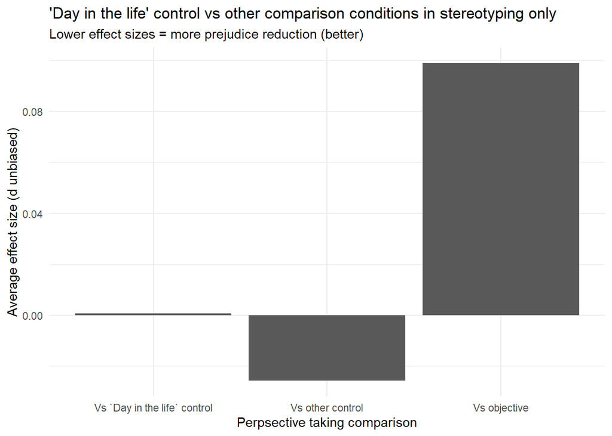

```r
emmeans_stereo2 %>% ggplot(aes(x = pt_comparison, y = emmean)) +
  geom_col() +
  theme_minimal() +
  labs(title = "'Day in the life' control vs other comparison conditions in stereotyping only",
       subtitle = "Lower effect sizes = more prejudice reduction (better)",
       x = "Perpsective taking comparison",
       y = "Average effect size (d unbiased)") +
  scale_x_discrete(labels = c('Vs `Day in the life` control','Vs other control',
                              'Vs objective'))
```

The marginal main effects do not differ from 0.

### Overall I2

```r
get_I2_overall(meta_stereo2, stereo_meta2)
```

```
## [1] 91.37103
```

Heterogeneity is high.

### I2 for levels of variance

*Left value corresponds to top sigma in Variance components output in model results (Sample_number_total). Right-most value corresponds to bottom sigma (Outcome_scale group).*

```r
get_I2_var_levels(meta_stereo2, stereo_meta2)
```

```
## [1] 63.86  9.21 13.12  5.18
```

Most hetereogeneity is explained by between-study variance, followed by between-condition variance.

## Moderators for “day in the life” model

### Scales of measurement

```r
stereo_meta2_mod1 <- rma.mv(dunb,
                      var_dunb,
                      mods = ~ pt_comparison*outcome_scale_group,
                      random = list(~ 1 | sample_number_total/outcomes_within_sample_var/conditions_within_sample_var), data = meta_stereo2)

stereo_meta2_mod1
```

```
##
## Multivariate Meta-Analysis Model (k = 138; method: REML)
##
## Variance Components:
##
##             estim    sqrt  nlvls  fixed
## sigma^2.1  0.3450  0.5874     61     no
## sigma^2.2  0.0790  0.2811    112     no
## sigma^2.3  0.0437  0.2092    125     no
##                                                                                 factor
## sigma^2.1                                                          sample_number_total
## sigma^2.2                               sample_number_total/outcomes_within_sample_var
## sigma^2.3  sample_number_total/outcomes_within_sample_var/conditions_within_sample_var
##
## Test for Residual Heterogeneity:
## QE(df = 122) = 702.7946, p-val < .0001
##
## Test of Moderators (coefficients 2:16):
## QM(df = 15) = 15.3660, p-val = 0.4254
##
## Model Results:
##
##                                                       estimate      se     zval
## intrcpt                                                -0.3304  0.3630  -0.9101
## pt_comparisonpt_v_other_control                         0.1922  0.7548   0.2546
## pt_comparisonpt_v_objective                             0.2019  0.6341   0.3184
## outcome_scale_group2                                    0.4252  0.4824   0.8814
## outcome_scale_group3                                    0.1768  0.4226   0.4183
## outcome_scale_group4                                    0.3975  0.6201   0.6409
## outcome_scale_group5                                    0.8620  0.4536   1.9004
## outcome_scale_group6                                    0.0073  0.4124   0.0178
## pt_comparisonpt_v_other_control:outcome_scale_group2   -0.5097  0.8525  -0.5979
## pt_comparisonpt_v_objective:outcome_scale_group2        0.0327  0.7520   0.0434
## pt_comparisonpt_v_objective:outcome_scale_group3       -0.1907  0.7185  -0.2655
## pt_comparisonpt_v_other_control:outcome_scale_group4   -0.2959  0.9276  -0.3190
## pt_comparisonpt_v_objective:outcome_scale_group4       -0.3578  0.8313  -0.4304
## pt_comparisonpt_v_objective:outcome_scale_group5       -0.0862  0.7584  -0.1137
## pt_comparisonpt_v_other_control:outcome_scale_group6    0.1391  0.7990   0.1740
## pt_comparisonpt_v_objective:outcome_scale_group6        0.3799  0.6866   0.5532
##                                                         pval    ci.lb   ci.ub
```

[output cut: 21 more lines]

```
## outcome_scale_group3
## outcome_scale_group4
## outcome_scale_group5                                  .
## outcome_scale_group6
## pt_comparisonpt_v_other_control:outcome_scale_group2
## pt_comparisonpt_v_objective:outcome_scale_group2
## pt_comparisonpt_v_objective:outcome_scale_group3
## pt_comparisonpt_v_other_control:outcome_scale_group4
## pt_comparisonpt_v_objective:outcome_scale_group4
## pt_comparisonpt_v_objective:outcome_scale_group5
## pt_comparisonpt_v_other_control:outcome_scale_group6
## pt_comparisonpt_v_objective:outcome_scale_group6
##
## ---
## Signif. codes:  0 '***' 0.001 '**' 0.01 '*' 0.05 '.' 0.1 ' ' 1
```

Nothing is significant from one another, and the intercept is not significantly different from 0. Outcome scale group 5 (Essay stereotypicality) is marginally different from the intercept outcome scale group 1 (IAT). Rma.mv dropped cells with 0 due to redundancies, and therefore cannot be modeled in emmeans.

#### I2 overall

```r
get_I2_overall(meta_stereo2, stereo_meta2_mod1)
```

```
## [1] 91.55907
```

About the same as the model without moderators.

#### I2 for levels of variance

*Left value corresponds to top sigma in Variance components output in model results (Sample_number_total). Right-most value corresponds to bottom sigma (Outcome_scale group).*

```r
get_I2_var_levels(meta_stereo2, stereo_meta2_mod1)
```

```
## [1] 67.53 15.47  8.56
```

Most hetereogeneity is explained by between-studies variance, followed by between-outcomes (within-study) variance.

### Target moderator - information amount

```r
stereo_meta2_mod2 <- rma.mv(dunb,
                      var_dunb,
                      mods = ~ pt_comparison*target_information,
                      random = list(~ 1 | sample_number_total/outcomes_within_sample_var/conditions_within_sample_var,
                                    ~ 1 | outcome_scale_group), data = meta_stereo2)

stereo_meta2_mod2
```

```
##
## Multivariate Meta-Analysis Model (k = 138; method: REML)
##
## Variance Components:
##
##             estim    sqrt  nlvls  fixed
## sigma^2.1  0.3740  0.6115     61     no
## sigma^2.2  0.0961  0.3100    112     no
## sigma^2.3  0.0178  0.1335    125     no
## sigma^2.4  0.0158  0.1258      6     no
##                                                                                 factor
## sigma^2.1                                                          sample_number_total
## sigma^2.2                               sample_number_total/outcomes_within_sample_var
## sigma^2.3  sample_number_total/outcomes_within_sample_var/conditions_within_sample_var
## sigma^2.4                                                          outcome_scale_group
##
## Test for Residual Heterogeneity:
## QE(df = 129) = 757.7391, p-val < .0001
##
## Test of Moderators (coefficients 2:9):
## QM(df = 8) = 10.3872, p-val = 0.2389
##
## Model Results:
##
##                                                      estimate      se     zval
## intrcpt                                               -0.1849  0.2332  -0.7927
## pt_comparisonpt_v_other_control                        0.4064  0.3454   1.1766
## pt_comparisonpt_v_objective                            0.1755  0.2983   0.5884
## target_information2                                    0.8290  0.7035   1.1783
## target_information3                                    0.4694  0.4527   1.0369
## pt_comparisonpt_v_other_control:target_information2   -1.5060  0.7870  -1.9136
## pt_comparisonpt_v_objective:target_information2       -0.6408  0.7588  -0.8445
## pt_comparisonpt_v_other_control:target_information3   -0.4914  0.5827  -0.8433
## pt_comparisonpt_v_objective:target_information3       -0.3069  0.5383  -0.5702
##                                                        pval    ci.lb   ci.ub
## intrcpt                                              0.4279  -0.6420  0.2722
## pt_comparisonpt_v_other_control                      0.2393  -0.2706  1.0834
## pt_comparisonpt_v_objective                          0.5563  -0.4091  0.7601
## target_information2                                  0.2387  -0.5499  2.2079
## target_information3                                  0.2998  -0.4178  1.3567
## pt_comparisonpt_v_other_control:target_information2  0.0557  -3.0485  0.0365  .
## pt_comparisonpt_v_objective:target_information2      0.3984  -2.1280  0.8464
## pt_comparisonpt_v_other_control:target_information3  0.3990  -1.6335  0.6507
## pt_comparisonpt_v_objective:target_information3      0.5686  -1.3620  0.7481
##
## ---
## Signif. codes:  0 '***' 0.001 '**' 0.01 '*' 0.05 '.' 0.1 ' ' 1
```

Pt v other control with medium target information is marginally different from the intercept (p vs “day in the life” control with impoverished information). Nothing else is significant from the intercept, nor is the intercept significant.

#### Marginal main effect

```r
qdrq_stereo2_mod2 <- qdrg(object = stereo_meta2_mod2, data = meta_stereo2)

emmeans_stereo2_mod2 <- summary(emmeans(qdrq_stereo2_mod2, "pt_comparison", "target_information"))
emmeans_stereo2_mod2
```

```
## target_information = 1:
##  pt_comparison        emmean    SE  df asymp.LCL asymp.UCL
##  pt_v_day_control   -0.18487 0.233 Inf    -0.642    0.2722
##  pt_v_other_control  0.22152 0.265 Inf    -0.299    0.7416
##  pt_v_objective     -0.00938 0.202 Inf    -0.406    0.3869
##
## target_information = 2:
##  pt_comparison        emmean    SE  df asymp.LCL asymp.UCL
##  pt_v_day_control    0.64415 0.668 Inf    -0.664    1.9527
##  pt_v_other_control -0.45544 0.248 Inf    -0.942    0.0313
##  pt_v_objective      0.17881 0.213 Inf    -0.239    0.5967
##
## target_information = 3:
##  pt_comparison        emmean    SE  df asymp.LCL asymp.UCL
##  pt_v_day_control    0.28454 0.396 Inf    -0.491    1.0598
##  pt_v_other_control  0.19953 0.263 Inf    -0.317    0.7159
##  pt_v_objective      0.15311 0.217 Inf    -0.272    0.5781
##
## Confidence level used: 0.95
```

None of the effect sizes significantly differ from 0 when looking at the marginal means when broken down by target information.

#### I2 overall

```r
get_I2_overall(meta_stereo2, stereo_meta2_mod2)
```

```
## [1] 92.01171
```

Slightly higher than the original model without moderators.

#### I2 for levels of variance

*Left value corresponds to top sigma in Variance components output in model results (Sample_number_total). Right-most value corresponds to bottom sigma (Outcome_scale group).*

```r
get_I2_var_levels(meta_stereo2, stereo_meta2_mod2)
```

```
## [1] 68.31 17.55  3.26  2.89
```

Most hetereogeneity is explained by between-studies variance, followed by between-outcomes (within-study) variance.

### Target moderator - target out-group

```r
stereo2_group_data <- meta_stereo2 %>%
  select(dunb, var_dunb, pt_comparison, target_out_minor, sample_number_total,
         outcomes_within_sample_var, conditions_within_sample_var, outcome_scale_group) %>%
  na.omit()

stereo_meta2_mod3 <- rma.mv(dunb,
                      var_dunb,
                      mods = ~ pt_comparison*target_out_minor,
                      random = list(~ 1 | sample_number_total/outcomes_within_sample_var/conditions_within_sample_var,
                                    ~ 1 | outcome_scale_group), data = stereo2_group_data)

stereo_meta2_mod3
```

```
##
## Multivariate Meta-Analysis Model (k = 135; method: REML)
##
## Variance Components:
##
##             estim    sqrt  nlvls  fixed
## sigma^2.1  0.3561  0.5968     61     no
## sigma^2.2  0.0597  0.2444    109     no
## sigma^2.3  0.0693  0.2633    122     no
## sigma^2.4  0.0124  0.1113      6     no
##                                                                                 factor
## sigma^2.1                                                          sample_number_total
## sigma^2.2                               sample_number_total/outcomes_within_sample_var
## sigma^2.3  sample_number_total/outcomes_within_sample_var/conditions_within_sample_var
## sigma^2.4                                                          outcome_scale_group
##
## Test for Residual Heterogeneity:
## QE(df = 129) = 746.1253, p-val < .0001
##
## Test of Moderators (coefficients 2:6):
## QM(df = 5) = 28.9418, p-val < .0001
##
## Model Results:
##
##                                                    estimate      se     zval
## intrcpt                                             -0.4916  0.2127  -2.3107
## pt_comparisonpt_v_other_control                      0.5353  0.2941   1.8198
## pt_comparisonpt_v_objective                          0.5492  0.2762   1.9883
## target_out_minor2                                    0.7138  0.1350   5.2872
## pt_comparisonpt_v_other_control:target_out_minor2   -0.8615  0.2929  -2.9413
## pt_comparisonpt_v_objective:target_out_minor2       -0.6695  0.2743  -2.4406
##                                                      pval    ci.lb    ci.ub
## intrcpt                                            0.0208  -0.9085  -0.0746
## pt_comparisonpt_v_other_control                    0.0688  -0.0412   1.1118
## pt_comparisonpt_v_objective                        0.0468   0.0078   1.0906
## target_out_minor2                                  <.0001   0.4492   0.9784
## pt_comparisonpt_v_other_control:target_out_minor2  0.0033  -1.4356  -0.2874
## pt_comparisonpt_v_objective:target_out_minor2      0.0147  -1.2071  -0.1319
##
## intrcpt                                              *
## pt_comparisonpt_v_other_control                      .
## pt_comparisonpt_v_objective                          *
## target_out_minor2                                  ***
## pt_comparisonpt_v_other_control:target_out_minor2   **
## pt_comparisonpt_v_objective:target_out_minor2        *
##
## ---
## Signif. codes:  0 '***' 0.001 '**' 0.01 '*' 0.05 '.' 0.1 ' ' 1
```

The intercept (pt v day in the life control with out-group target) is significantly different from 0. Pt v control is marginally different from the intercept, and pt v objective is significantly different from the intercept. The simple main effect of target out-group group is significant: in the “day in the life” control, there are higher positive effect sizes (less prejudice reduction) for non-out-group/minority targets than out-group/minority targets. The interactions are also significant, indicating there are differences between the differences for both pt_v_control with a non-out-group minority target and p_v_objective with a non-out-group/minority target in comparison to the intercept. The marginal main effects will show the estimates of each of these comparisons better, as well as if they differ from 0.

#### Marginal main effects

```r
qdrq_stereo2_mod3 <- qdrg(object = stereo_meta2_mod3, data = stereo2_group_data)

emmeans_stereo2_mod3 <- summary(emmeans(qdrq_stereo2_mod3, "pt_comparison", "target_out_minor"))
emmeans_stereo2_mod3
```

```
## target_out_minor = 1:
##  pt_comparison       emmean    SE  df asymp.LCL asymp.UCL
##  pt_v_day_control   -0.4916 0.213 Inf    -0.909   -0.0746
##  pt_v_other_control  0.0437 0.211 Inf    -0.370    0.4572
##  pt_v_objective      0.0576 0.186 Inf    -0.307    0.4222
##
## target_out_minor = 2:
##  pt_comparison       emmean    SE  df asymp.LCL asymp.UCL
##  pt_v_day_control    0.2222 0.198 Inf    -0.166    0.6107
##  pt_v_other_control -0.1040 0.209 Inf    -0.514    0.3064
##  pt_v_objective      0.1019 0.166 Inf    -0.223    0.4267
##
## Confidence level used: 0.95
```

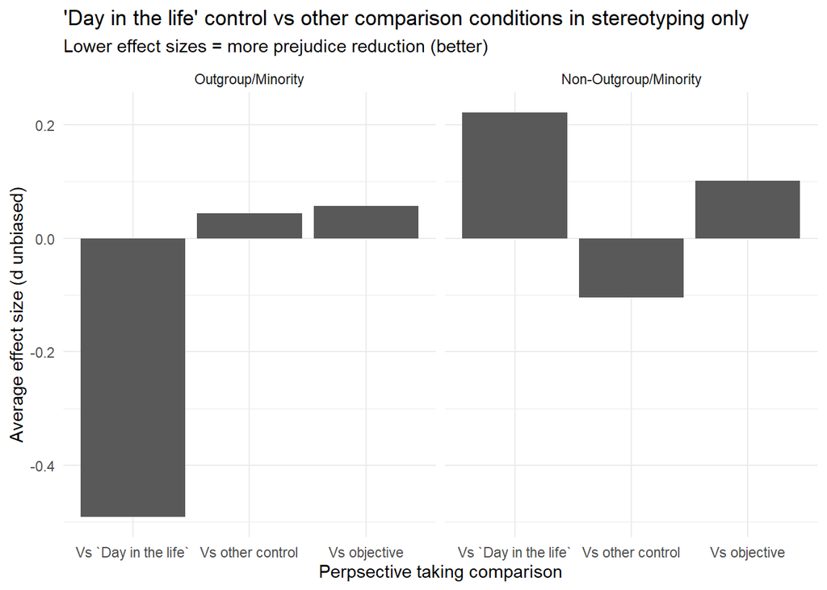

```r
outgroup_label <- c("1" = "Outgroup/Minority", "2" = "Non-Outgroup/Minority")

emmeans_stereo2_mod3 %>% ggplot(aes(x = pt_comparison, y = emmean)) +
  facet_grid(cols = vars(target_out_minor),
             labeller = labeller(target_out_minor = outgroup_label)) +
  geom_col() +
  theme_minimal() +
  labs(title = "'Day in the life' control vs other comparison conditions in stereotyping only",
       subtitle = "Lower effect sizes = more prejudice reduction (better)",
       x = "Perpsective taking comparison",
       y = "Average effect size (d unbiased)") +
  scale_x_discrete(labels = c('Vs `Day in the life`','Vs other control',
                              'Vs objective'))
```

#### I2 overall

```r
get_I2_overall(stereo2_group_data, stereo_meta2_mod3)
```

```
## [1] 91.78259
```

About the same as the model without moderaters.

#### I2 for levels of variance

*Left value corresponds to top sigma in Variance components output in model results (Sample_number_total). Right-most value corresponds to bottom sigma (Outcome_scale group).*

```r
get_I2_var_levels(stereo2_group_data, stereo_meta2_mod3)
```

```
## [1] 65.69 11.02 12.79  2.29
```

Most heterogeneity explained by between-studies variance, or between-conditions variance.

### Sample size

```r
stereo_meta2_mod4 <- rma.mv(dunb,
                      var_dunb,
                      mods = ~ pt_comparison*n_overall,
                      random = list(~ 1 | sample_number_total/outcomes_within_sample_var/conditions_within_sample_var,
                                    ~ 1 | outcome_scale_group), data = meta_stereo2)

stereo_meta2_mod4
```

```
##
## Multivariate Meta-Analysis Model (k = 138; method: REML)
##
## Variance Components:
##
##             estim    sqrt  nlvls  fixed
## sigma^2.1  0.3403  0.5833     61     no
## sigma^2.2  0.0613  0.2477    112     no
## sigma^2.3  0.0525  0.2292    125     no
## sigma^2.4  0.0289  0.1700      6     no
##                                                                                 factor
## sigma^2.1                                                          sample_number_total
## sigma^2.2                               sample_number_total/outcomes_within_sample_var
## sigma^2.3  sample_number_total/outcomes_within_sample_var/conditions_within_sample_var
## sigma^2.4                                                          outcome_scale_group
##
## Test for Residual Heterogeneity:
## QE(df = 132) = 785.1110, p-val < .0001
##
## Test of Moderators (coefficients 2:6):
## QM(df = 5) = 2.2904, p-val = 0.8077
##
## Model Results:
##
##                                            estimate      se     zval    pval
## intrcpt                                     -0.1884  0.2884  -0.6531  0.5137
## pt_comparisonpt_v_other_control              0.2278  0.3528   0.6456  0.5186
## pt_comparisonpt_v_objective                  0.1885  0.3304   0.5705  0.5683
## n_overall                                    0.0026  0.0029   0.8773  0.3803
## pt_comparisonpt_v_other_control:n_overall   -0.0032  0.0033  -0.9649  0.3346
## pt_comparisonpt_v_objective:n_overall       -0.0015  0.0032  -0.4506  0.6523
##                                              ci.lb   ci.ub
## intrcpt                                    -0.7537  0.3769
## pt_comparisonpt_v_other_control            -0.4637  0.9193
## pt_comparisonpt_v_objective                -0.4591  0.8362
## n_overall                                  -0.0032  0.0083
## pt_comparisonpt_v_other_control:n_overall  -0.0097  0.0033
## pt_comparisonpt_v_objective:n_overall      -0.0078  0.0049
##
## ---
## Signif. codes:  0 '***' 0.001 '**' 0.01 '*' 0.05 '.' 0.1 ' ' 1
```

Sample size does not interact with pt comparison. None of the effects are significant.

#### I2 overall

```r
get_I2_overall(meta_stereo2, stereo_meta2_mod4)
```

```
## [1] 91.51142
```

Heterogeneity is the same as in the model without moderators.

#### I2 for levels of variance

*Left value corresponds to top sigma in Variance components output in model results (Sample_number_total). Right-most value corresponds to bottom sigma (Outcome_scale group).*

```r
get_I2_var_levels(meta_stereo2, stereo_meta2_mod4)
```

```
## [1] 64.46 11.62  9.95  5.48
```

Heterogeneity is explained by between-studies variance the most, followed almost equally by between-conditions and between-outcomes variance.

# Overlap

## Number of overall effects:

```r
overlap_data %>%
  count()
```

```
## # A tibble: 1 x 1
##       n
##   <int>
## 1    53
```

## Effects per comparison group:

```r
overlap_data %>%
  group_by(pt_comparison) %>%
  count()
```

```
## # A tibble: 2 x 2
## # Groups:   pt_comparison [2]
##   pt_comparison      n
##   <fct>          <int>
## 1 pt_v_objective    31
## 2 pt_v_control      22
```

## Results

*Note: this comparison is the same as in the overall model interacting with outcome types, as the small k per cell in the overlap/merging category was the reason we had to collapse cross other perspective taking comparisons in that overall model.*

**Contrasts:**

```r
contrasts(overlap_data$pt_comparison)
```

```
##                pt_v_control
## pt_v_objective            0
## pt_v_control              1
```

```r
overlap_data$outcome_scale_group <- droplevels(overlap_data$outcome_scale_group)
levels(overlap_data$outcome_scale_group)
```

```
## [1] "7" "8" "9"
```

```r
overlap_pt <- rma.mv(dunb,
                      var_dunb,
                      mods = ~ pt_comparison,
                      random = list(~ 1 | sample_number_total/outcomes_within_sample_var/conditions_within_sample_var,
                                    ~ 1 | outcome_scale_group), data = overlap_data)

overlap_pt
```

```
##
## Multivariate Meta-Analysis Model (k = 53; method: REML)
##
## Variance Components:
##
##             estim    sqrt  nlvls  fixed
## sigma^2.1  0.1918  0.4379     32     no
## sigma^2.2  0.0169  0.1300     38     no
## sigma^2.3  0.0000  0.0000     49     no
## sigma^2.4  0.0618  0.2486      3     no
##                                                                                 factor
## sigma^2.1                                                          sample_number_total
## sigma^2.2                               sample_number_total/outcomes_within_sample_var
## sigma^2.3  sample_number_total/outcomes_within_sample_var/conditions_within_sample_var
## sigma^2.4                                                          outcome_scale_group
##
## Test for Residual Heterogeneity:
## QE(df = 51) = 307.2560, p-val < .0001
##
## Test of Moderators (coefficient 2):
## QM(df = 1) = 0.7615, p-val = 0.3828
##
## Model Results:
##
##                            estimate      se     zval    pval    ci.lb   ci.ub
## intrcpt                      0.3215  0.1819   1.7671  0.0772  -0.0351  0.6780
## pt_comparisonpt_v_control   -0.0690  0.0791  -0.8727  0.3828  -0.2240  0.0860
##
## intrcpt                    .
## pt_comparisonpt_v_control
##
## ---
## Signif. codes:  0 '***' 0.001 '**' 0.01 '*' 0.05 '.' 0.1 ' ' 1
```

The intercept is marginally different from zero. The pt v control condition does not differ significantly from the intercept.

### Marginal main effect

```r
qdrq_overlap <- qdrg(object = overlap_pt, data = overlap_data)

emmeans_overlap <- summary(emmeans(qdrq_overlap, "pt_comparison"))
emmeans_overlap
```

```
##  pt_comparison  emmean    SE  df asymp.LCL asymp.UCL
##  pt_v_objective  0.321 0.182 Inf   -0.0351     0.678
##  pt_v_control    0.252 0.182 Inf   -0.1043     0.609
##
## Confidence level used: 0.95
```

This comparison is the same as the overall model. Without the interaction, the values change slightly, but the pattern and significance do not.

### I2 overall model

```r
get_I2_overall(overlap_data, overlap_pt)
```

```
## [1] 87.82241
```

This heterogeneity is still high, but lower than with the stereotyping outcome or the overall model with perspective taking interacting with outcome type.

### I2 for levels of variance

*Left value corresponds to top sigma in Variance components output in model results (Sample_number_total). Right-most value corresponds to bottom sigma (Outcome_scale group).*

```r
get_I2_var_levels(overlap_data, overlap_pt)
```

```
## [1] 62.27  5.49  0.00 20.06
```

Most of the heterogeneity is due to between-studies variance. However, a large amount is also due to scales of measurement in the crossed struture.

## Moderators

### Scale of measurement

```r
overlap_data %>%
  group_by(outcome_scale_group) %>%
  count()
```

```
## # A tibble: 3 x 2
## # Groups:   outcome_scale_group [3]
##   outcome_scale_group     n
##   <fct>               <int>
## 1 7                      32
## 2 8                      16
## 3 9                       5
```

```r
overlap_model_mod1 <- rma.mv(dunb,
                      var_dunb,
                      mods = ~ pt_comparison*outcome_scale_group,
                      random = list(~ 1 | sample_number_total/outcomes_within_sample_var/conditions_within_sample_var),
                      data = overlap_data)

overlap_model_mod1
```

```
##
## Multivariate Meta-Analysis Model (k = 53; method: REML)
##
## Variance Components:
##
##             estim    sqrt  nlvls  fixed
## sigma^2.1  0.2099  0.4581     32     no
## sigma^2.2  0.0125  0.1119     38     no
## sigma^2.3  0.0000  0.0000     49     no
##                                                                                 factor
## sigma^2.1                                                          sample_number_total
## sigma^2.2                               sample_number_total/outcomes_within_sample_var
## sigma^2.3  sample_number_total/outcomes_within_sample_var/conditions_within_sample_var
##
## Test for Residual Heterogeneity:
## QE(df = 47) = 259.4843, p-val < .0001
##
## Test of Moderators (coefficients 2:6):
## QM(df = 5) = 10.4282, p-val = 0.0640
##
## Model Results:
##
##                                                 estimate      se     zval
## intrcpt                                           0.6080  0.1165   5.2207
## pt_comparisonpt_v_control                        -0.0841  0.0835  -1.0072
## outcome_scale_group8                             -0.3551  0.1684  -2.1085
## outcome_scale_group9                             -0.8043  0.3596  -2.2367
## pt_comparisonpt_v_control:outcome_scale_group8   -0.0781  0.3199  -0.2441
## pt_comparisonpt_v_control:outcome_scale_group9    0.3345  0.3386   0.9881
##                                                   pval    ci.lb    ci.ub
## intrcpt                                         <.0001   0.3797   0.8362  ***
## pt_comparisonpt_v_control                       0.3138  -0.2478   0.0796
## outcome_scale_group8                            0.0350  -0.6852  -0.0250    *
## outcome_scale_group9                            0.0253  -1.5091  -0.0995    *
## pt_comparisonpt_v_control:outcome_scale_group8  0.8072  -0.7052   0.5490
## pt_comparisonpt_v_control:outcome_scale_group9  0.3231  -0.3290   0.9981
##
## ---
## Signif. codes:  0 '***' 0.001 '**' 0.01 '*' 0.05 '.' 0.1 ' ' 1
```

Scale 7 (Self-report IOS merging/scales) while in the pt vs objective comparison is the reference group. These are simple effects in which the effect sizes become significantly lower for the pt vs objective comparison when merging is measured from overlap of traits/attributes or measures of social distancing. There are no interactions.

#### Marginal main effects

```r
qdrq_overlap2 <- qdrg(object = overlap_model_mod1, data = overlap_data)

emmeans_overlap2 <- summary(emmeans(qdrq_overlap2, "pt_comparison", "outcome_scale_group"))
emmeans_overlap2
```

```
## outcome_scale_group = 7:
##  pt_comparison   emmean    SE  df asymp.LCL asymp.UCL
##  pt_v_objective  0.6080 0.116 Inf    0.3797     0.836
##  pt_v_control    0.5239 0.119 Inf    0.2913     0.756
##
## outcome_scale_group = 8:
##  pt_comparison   emmean    SE  df asymp.LCL asymp.UCL
##  pt_v_objective  0.2529 0.170 Inf   -0.0804     0.586
##  pt_v_control    0.0907 0.264 Inf   -0.4273     0.609
##
## outcome_scale_group = 9:
##  pt_comparison   emmean    SE  df asymp.LCL asymp.UCL
##  pt_v_objective -0.1963 0.340 Inf   -0.8631     0.470
##  pt_v_control    0.0541 0.331 Inf   -0.5944     0.703
##
## Confidence level used: 0.95
```

When using a self-reported merging scale both pt vs objective and control lead to medium to large effect sizes that differed from 0. When using both the attribution and social distance scales, neither comparison significantly differed from 0.

#### I2 overall

```r
get_I2_overall(overlap_data, overlap_model_mod1)
```

```
## [1] 85.29702
```

With this moderator, the heterogeneity lessens a bit.

#### I2 for levels of variance

*Left value corresponds to top sigma in Variance components output in model results (Sample_number_total). Right-most value corresponds to bottom sigma (Outcome_scale group).*

```r
get_I2_var_levels(overlap_data, overlap_model_mod1)
```

```
## [1] 80.49  4.80  0.00
```

Almost all of the heterogeneity can be explained by between-studies variance.

### Target - amount of information

```r
overlap_model_mod2 <- rma.mv(dunb,
                      var_dunb,
                      mods = ~ pt_comparison*target_information,
                      random = list(~ 1 | sample_number_total/outcomes_within_sample_var/conditions_within_sample_var,
                                    ~ 1 | outcome_scale_group),
                      data = overlap_data)

overlap_model_mod2
```

```
##
## Multivariate Meta-Analysis Model (k = 53; method: REML)
##
## Variance Components:
##
##             estim    sqrt  nlvls  fixed
## sigma^2.1  0.1278  0.3575     32     no
## sigma^2.2  0.0312  0.1765     38     no
## sigma^2.3  0.0000  0.0000     49     no
## sigma^2.4  0.0422  0.2054      3     no
##                                                                                 factor
## sigma^2.1                                                          sample_number_total
## sigma^2.2                               sample_number_total/outcomes_within_sample_var
## sigma^2.3  sample_number_total/outcomes_within_sample_var/conditions_within_sample_var
## sigma^2.4                                                          outcome_scale_group
##
## Test for Residual Heterogeneity:
## QE(df = 47) = 177.2239, p-val < .0001
##
## Test of Moderators (coefficients 2:6):
## QM(df = 5) = 11.7904, p-val = 0.0378
##
## Model Results:
##
##                                                estimate      se     zval
## intrcpt                                          0.4257  0.2729   1.5598
## pt_comparisonpt_v_control                       -0.0133  0.2682  -0.0497
## target_information2                             -0.3084  0.3044  -1.0130
## target_information3                             -0.0347  0.2786  -0.1246
## pt_comparisonpt_v_control:target_information2   -0.1671  0.2889  -0.5784
## pt_comparisonpt_v_control:target_information3    0.2194  0.3003   0.7305
##                                                  pval    ci.lb   ci.ub
## intrcpt                                        0.1188  -0.1092  0.9607
## pt_comparisonpt_v_control                      0.9603  -0.5390  0.5123
## target_information2                            0.3110  -0.9050  0.2883
## target_information3                            0.9009  -0.5807  0.5113
## pt_comparisonpt_v_control:target_information2  0.5630  -0.7333  0.3991
## pt_comparisonpt_v_control:target_information3  0.4651  -0.3692  0.8079
##
## ---
## Signif. codes:  0 '***' 0.001 '**' 0.01 '*' 0.05 '.' 0.1 ' ' 1
```

None are significant. I2 lowered.

#### Marginal main effects

```r
qdrq_overlap3 <- qdrg(object = overlap_model_mod2, data = overlap_data)

emmeans_overlap3 <- summary(emmeans(qdrq_overlap3, "pt_comparison", "target_information"))
emmeans_overlap3
```

```
## target_information = 1:
##  pt_comparison   emmean    SE  df asymp.LCL asymp.UCL
##  pt_v_objective  0.4257 0.273 Inf   -0.1092     0.961
##  pt_v_control    0.4124 0.224 Inf   -0.0273     0.852
##
## target_information = 2:
##  pt_comparison   emmean    SE  df asymp.LCL asymp.UCL
##  pt_v_objective  0.1174 0.216 Inf   -0.3056     0.540
##  pt_v_control   -0.0631 0.198 Inf   -0.4515     0.325
##
## target_information = 3:
##  pt_comparison   emmean    SE  df asymp.LCL asymp.UCL
##  pt_v_objective  0.3910 0.178 Inf    0.0417     0.740
##  pt_v_control    0.5970 0.208 Inf    0.1902     1.004
##
## Confidence level used: 0.95
```

When target information is impoverished, tneither comparison significantly differs from 0. Regardless of comparison condition, the effect does not significantly differ from 0 when target information was rated a 2. When target information is rated as highly detailed, both pt comparisons differ from 0. The objective comparison condition led to a medium effect size, while the control comparison lead a medium to large effect size.

#### Overall I2

```r
get_I2_overall(overlap_data, overlap_model_mod2)
```

```
## [1] 83.94748
```

Heterogeneity is even lower when including target information in the model.

#### I2 for levels of variance

*Left value corresponds to top sigma in Variance components output in model results (Sample_number_total). Right-most value corresponds to bottom sigma (Outcome_scale group).*

```r
get_I2_var_levels(overlap_data, overlap_model_mod2)
```

```
## [1] 53.34 13.01  0.00 17.61
```

Most of this heterogeneity is attributed to between-studies variance, with variance due to scales of measurement (17%) and then between-outcomes attributing to similar amounts (13%).

With there being no redundancies in the model and lower I2, I wonder if we can model an interaction with scale?

### Both scale & target info

```r
#Modeled target information as a main effect since it had no interactions and, because, when I tried to model it with interactions it led to redundancies

overlap_data %>%
  group_by(pt_comparison, outcome_scale_group, target_information) %>%
  count()
```

```
## # A tibble: 13 x 4
## # Groups:   pt_comparison, outcome_scale_group, target_information [13]
##    pt_comparison  outcome_scale_group target_information     n
##    <fct>          <fct>               <fct>              <int>
##  1 pt_v_objective 7                   2                      4
##  2 pt_v_objective 7                   3                     14
##  3 pt_v_objective 8                   1                      3
##  4 pt_v_objective 8                   3                      7
##  5 pt_v_objective 9                   1                      1
##  6 pt_v_objective 9                   3                      2
##  7 pt_v_control   7                   1                      3
##  8 pt_v_control   7                   2                      6
##  9 pt_v_control   7                   3                      5
## 10 pt_v_control   8                   1                      2
## 11 pt_v_control   8                   2                      4
## 12 pt_v_control   9                   1                      1
## 13 pt_v_control   9                   2                      1
```

```r
2*3*3
```

```
## [1] 18
```

```r
#Should be 18 but there are 13, so the redundancies come from the fact that there are cells with 0 in it, which rma.mv is dropping: https://stats.stackexchange.com/questions/223918/multilevel-metaregression-in-r-redundant-predictors-dropped-metafor

overlap_model_mod3 <- rma.mv(dunb,
                      var_dunb,
                      mods = ~ pt_comparison*outcome_scale_group*target_information,
                      random = list(~ 1 | sample_number_total/outcomes_within_sample_var/conditions_within_sample_var),
                      data = overlap_data)

overlap_model_mod3
```

```
##
## Multivariate Meta-Analysis Model (k = 53; method: REML)
##
## Variance Components:
##
##             estim    sqrt  nlvls  fixed
## sigma^2.1  0.1273  0.3568     32     no
## sigma^2.2  0.0000  0.0000     38     no
## sigma^2.3  0.0000  0.0000     49     no
##                                                                                 factor
## sigma^2.1                                                          sample_number_total
## sigma^2.2                               sample_number_total/outcomes_within_sample_var
## sigma^2.3  sample_number_total/outcomes_within_sample_var/conditions_within_sample_var
##
## Test for Residual Heterogeneity:
## QE(df = 40) = 128.0142, p-val < .0001
##
## Test of Moderators (coefficients 2:13):
## QM(df = 12) = 39.1891, p-val < .0001
##
## Model Results:
##
##                                                 estimate      se     zval
## intrcpt                                           0.0298  0.6290   0.0474
## pt_comparisonpt_v_control                         0.1625  0.6748   0.2408
## outcome_scale_group8                              0.7712  0.6986   1.1039
## outcome_scale_group9                             -0.4738  0.4467  -1.0606
## target_information2                               0.4005  0.6568   0.6097
## target_information3                               0.6033  0.6172   0.9776
## pt_comparisonpt_v_control:outcome_scale_group8   -0.0687  0.8112  -0.0848
## pt_comparisonpt_v_control:outcome_scale_group9    0.2124  0.6736   0.3153
## pt_comparisonpt_v_control:target_information2    -0.3336  0.6831  -0.4883
## pt_comparisonpt_v_control:target_information3     0.0389  0.6808   0.0572
## outcome_scale_group8:target_information2         -1.4960  0.5275  -2.8362
## outcome_scale_group9:target_information2         -0.0747  0.6543  -0.1141
## outcome_scale_group8:target_information3         -1.2589  0.7092  -1.7752
##                                                   pval    ci.lb    ci.ub
## intrcpt                                         0.9622  -1.2030   1.2627
## pt_comparisonpt_v_control                       0.8097  -1.1602   1.4852
## outcome_scale_group8                            0.2697  -0.5981   2.1405
## outcome_scale_group9                            0.2889  -1.3492   0.4017
## target_information2                             0.5420  -0.8868   1.6878
## target_information3                             0.3283  -0.6063   1.8129
## pt_comparisonpt_v_control:outcome_scale_group8  0.9325  -1.6586   1.5211
## pt_comparisonpt_v_control:outcome_scale_group9  0.7525  -1.1079   1.5326
## pt_comparisonpt_v_control:target_information2   0.6253  -1.6723   1.0052
## pt_comparisonpt_v_control:target_information3   0.9544  -1.2955   1.3733
## outcome_scale_group8:target_information2        0.0046  -2.5299  -0.4622  **
## outcome_scale_group9:target_information2        0.9091  -1.3571   1.2077
## outcome_scale_group8:target_information3        0.0759  -2.6489   0.1310   .
##
## ---
## Signif. codes:  0 '***' 0.001 '**' 0.01 '*' 0.05 '.' 0.1 ' ' 1
```

The I2 decreases having all three predictors in the model, though it is concerning that some cells are 0 and that was causing redundancies. Cannot model with emmeans because of redundancies.

#### I2 overall

```r
get_I2_overall(overlap_data, overlap_model_mod3)
```

```
## [1] 76.69843
```

#### I2 for levels of variance

*Left value corresponds to top sigma in Variance components output in model results (Sample_number_total). Right-most value corresponds to bottom sigma (Outcome_scale group).*

```r
get_I2_var_levels(overlap_data, overlap_model_mod3)
```

```
## [1] 76.7  0.0  0.0
```

All variance is explained by between-studies variance. This is probably due to k being too small per cell.

### Target - In-group target grouping (relevant to outcome category)

```r
overlap_data <- overlap_data %>%
  filter(target_ingroup_nonspecific == "1" | target_ingroup_nonspecific == "2")

overlap_data$target_ingroup_nonspecific <- droplevels(overlap_data$target_ingroup_nonspecific)

overlap_model_mod4 <- rma.mv(dunb,
                      var_dunb,
                      mods = ~ pt_comparison*target_ingroup_nonspecific,
                      random = list(~ 1 | sample_number_total/outcomes_within_sample_var/conditions_within_sample_var,
                                    ~ 1 | outcome_scale_group),
                      data = overlap_data)

overlap_model_mod4
```

```
##
## Multivariate Meta-Analysis Model (k = 48; method: REML)
##
## Variance Components:
##
##             estim    sqrt  nlvls  fixed
## sigma^2.1  0.1654  0.4067     30     no
## sigma^2.2  0.0631  0.2512     33     no
## sigma^2.3  0.0000  0.0000     44     no
## sigma^2.4  0.0077  0.0879      3     no
##                                                                                 factor
## sigma^2.1                                                          sample_number_total
## sigma^2.2                               sample_number_total/outcomes_within_sample_var
## sigma^2.3  sample_number_total/outcomes_within_sample_var/conditions_within_sample_var
## sigma^2.4                                                          outcome_scale_group
##
## Test for Residual Heterogeneity:
## QE(df = 44) = 290.7331, p-val < .0001
##
## Test of Moderators (coefficients 2:4):
## QM(df = 3) = 2.7955, p-val = 0.4242
##
## Model Results:
##
##                                                        estimate      se
## intrcpt                                                  0.5303  0.1435
## pt_comparisonpt_v_control                               -0.0983  0.0948
## target_ingroup_nonspecific2                             -0.2210  0.1585
## pt_comparisonpt_v_control:target_ingroup_nonspecific2    0.1314  0.1825
##                                                           zval    pval    ci.lb
## intrcpt                                                 3.6962  0.0002   0.2491
## pt_comparisonpt_v_control                              -1.0369  0.2998  -0.2840
## target_ingroup_nonspecific2                            -1.3938  0.1634  -0.5317
## pt_comparisonpt_v_control:target_ingroup_nonspecific2   0.7201  0.4715  -0.2262
##                                                         ci.ub
## intrcpt                                                0.8115  ***
## pt_comparisonpt_v_control                              0.0875
## target_ingroup_nonspecific2                            0.0898
## pt_comparisonpt_v_control:target_ingroup_nonspecific2  0.4890
##
## ---
## Signif. codes:  0 '***' 0.001 '**' 0.01 '*' 0.05 '.' 0.1 ' ' 1
```

The intercept (pt_v_objective when the target is your in-group) is significantly different from 0. No effects differ from the intercept. Tried running an out-group moderator model as well, but it had a convergence issue.

```r
qdrq_overlap4 <- qdrg(object = overlap_model_mod4, data = overlap_data)

emmeans_overlap4 <- summary(emmeans(qdrq_overlap4, "pt_comparison", "target_ingroup_nonspecific"))
emmeans_overlap4
```

```
## target_ingroup_nonspecific = 1:
##  pt_comparison  emmean    SE  df asymp.LCL asymp.UCL
##  pt_v_objective  0.530 0.143 Inf   0.24910     0.812
##  pt_v_control    0.432 0.153 Inf   0.13298     0.731
##
## target_ingroup_nonspecific = 2:
##  pt_comparison  emmean    SE  df asymp.LCL asymp.UCL
##  pt_v_objective  0.309 0.157 Inf   0.00245     0.616
##  pt_v_control    0.342 0.133 Inf   0.08209     0.603
##
## Confidence level used: 0.95
```

The marginal main effects indicate that the average effect size is highest when pt is compared to the objective condition and the target is an in-group target, followed by when the target is an in-group and pt is compared to the control. Both significantly differed from 0. The effect sizes when the target is not an in-group member border being non-significant and are about the same regardless of if pt is being compared to the objective (.31) or control condition (.34). Both are lower than the in-group effect sizes.

#### I2 overall

```r
get_I2_overall(overlap_data, overlap_model_mod4)
```

```
## [1] 86.61157
```

Heterogeneity is not as low as other moderators.

#### I2 for levels of variance

*Left value corresponds to top sigma in Variance components output in model results (Sample_number_total). Right-most value corresponds to bottom sigma (Outcome_scale group).*

```r
get_I2_var_levels(overlap_data, overlap_model_mod4)
```

```
## [1] 60.64 23.14  0.00  2.83
```

Most heterogeneity is explained by between-studies variance, followed by between-outcomes variance.

### Sample size

```r
overlap_model_mod5 <- rma.mv(dunb,
                      var_dunb,
                      mods = ~ pt_comparison*n_overall,
                      random = list(~ 1 | sample_number_total/outcomes_within_sample_var/conditions_within_sample_var,
                                    ~ 1 | outcome_scale_group),
                      data = overlap_data)

overlap_model_mod5
```

```
##
## Multivariate Meta-Analysis Model (k = 48; method: REML)
##
## Variance Components:
##
##             estim    sqrt  nlvls  fixed
## sigma^2.1  0.2067  0.4546     30     no
## sigma^2.2  0.0398  0.1995     33     no
## sigma^2.3  0.0000  0.0000     44     no
## sigma^2.4  0.0266  0.1631      3     no
##                                                                                 factor
## sigma^2.1                                                          sample_number_total
## sigma^2.2                               sample_number_total/outcomes_within_sample_var
## sigma^2.3  sample_number_total/outcomes_within_sample_var/conditions_within_sample_var
## sigma^2.4                                                          outcome_scale_group
##
## Test for Residual Heterogeneity:
## QE(df = 44) = 290.3469, p-val < .0001
##
## Test of Moderators (coefficients 2:4):
## QM(df = 3) = 1.7089, p-val = 0.6350
##
## Model Results:
##
##                                      estimate      se     zval    pval    ci.lb
## intrcpt                                0.4174  0.1969   2.1196  0.0340   0.0314
## pt_comparisonpt_v_control              0.0648  0.1986   0.3261  0.7444  -0.3245
## n_overall                             -0.0005  0.0011  -0.4385  0.6610  -0.0025
## pt_comparisonpt_v_control:n_overall   -0.0005  0.0007  -0.7185  0.4724  -0.0020
##                                       ci.ub
## intrcpt                              0.8034  *
## pt_comparisonpt_v_control            0.4540
## n_overall                            0.0016
## pt_comparisonpt_v_control:n_overall  0.0009
##
## ---
## Signif. codes:  0 '***' 0.001 '**' 0.01 '*' 0.05 '.' 0.1 ' ' 1
```

Intercept different from 0. No interaction with sample size.

#### I2 overall

```r
get_I2_overall(overlap_data, overlap_model_mod5)
```

```
## [1] 88.11935
```

Overall I2 is higher with this moderator.

#### I2 for levels of variance

*Left value corresponds to top sigma in Variance components output in model results (Sample_number_total). Right-most value corresponds to bottom sigma (Outcome_scale group).*

```r
get_I2_var_levels(overlap_data, overlap_model_mod5)
```

```
## [1] 66.69 12.84  0.00  8.59
```

Most heterogeneity is explained by between-studies variance.

# Interpersonal Feelings

```r
feels <- meta_data %>%
  mutate(pt_comparison = fct_collapse(pt_comparison,
                                      self_v_control = c("1", "2"),
                                      self_v_objective = c("3"),
                                      other_v_control = c( "6"),# there are no day in the life controls in the interpersonal feels category
                                      other_v_objective = c("7"))) %>%
  filter(pt_comparison == "self_v_control" | pt_comparison == "self_v_objective" |
           pt_comparison == "other_v_control" | pt_comparison == "other_v_objective") %>%
  mutate(pt_comparison = as.factor(droplevels(pt_comparison))) %>%
  mutate(pt_comparison = fct_relevel(pt_comparison,
                                     "self_v_objective",
                                     "self_v_control",
                                     "other_v_objective",
                                     "other_v_control"))
feels %<>%
  filter(outcome_type == "3")
```

## Number of overall effects:

```r
feels %>%
  count()
```

```
## # A tibble: 1 x 1
##       n
##   <int>
## 1   184
```

## Effects per comparison group:

```r
feels %>%
  group_by(pt_comparison) %>%
  count()
```

```
## # A tibble: 4 x 2
## # Groups:   pt_comparison [4]
##   pt_comparison         n
##   <fct>             <int>
## 1 self_v_objective     19
## 2 self_v_control       35
## 3 other_v_objective    62
## 4 other_v_control      68
```

19 is one under our limit of 20, so this will need to be taken as exploratory for the purposes of this preliminary analysis for my prelims. I want to look at these comparisons because they speak to McAuliffe et al’s meta-analytic results.

## Model results

**Contrasts:**

```r
contrasts(feels$pt_comparison)
```

```
##                   self_v_control other_v_objective other_v_control
## self_v_objective               0                 0               0
## self_v_control                 1                 0               0
## other_v_objective              0                 1               0
## other_v_control                0                 0               1
```

```r
feels$outcome_scale_group <- droplevels(feels$outcome_scale_group)

feels_model <- rma.mv(dunb,
                      var_dunb,
                      mods = ~ pt_comparison,
                      random = list(~ 1 | sample_number_total/outcomes_within_sample_var/conditions_within_sample_var,
                                    ~ 1 | outcome_scale_group), data = feels)

feels_model
```

```
##
## Multivariate Meta-Analysis Model (k = 184; method: REML)
##
## Variance Components:
##
##             estim    sqrt  nlvls  fixed
## sigma^2.1  0.3040  0.5514     88     no
## sigma^2.2  0.0270  0.1642    130     no
## sigma^2.3  0.0210  0.1451    178     no
## sigma^2.4  0.0485  0.2202      6     no
##                                                                                 factor
## sigma^2.1                                                          sample_number_total
## sigma^2.2                               sample_number_total/outcomes_within_sample_var
## sigma^2.3  sample_number_total/outcomes_within_sample_var/conditions_within_sample_var
## sigma^2.4                                                          outcome_scale_group
##
## Test for Residual Heterogeneity:
## QE(df = 180) = 998.9439, p-val < .0001
##
## Test of Moderators (coefficients 2:4):
## QM(df = 3) = 18.3691, p-val = 0.0004
##
## Model Results:
##
##                                 estimate      se     zval    pval    ci.lb
## intrcpt                           0.5099  0.1438   3.5452  0.0004   0.2280
## pt_comparisonself_v_control      -0.2528  0.1115  -2.2678  0.0233  -0.4712
## pt_comparisonother_v_objective    0.0362  0.0956   0.3788  0.7048  -0.1511
## pt_comparisonother_v_control     -0.2245  0.1014  -2.2130  0.0269  -0.4233
##                                   ci.ub
## intrcpt                          0.7918  ***
## pt_comparisonself_v_control     -0.0343    *
## pt_comparisonother_v_objective   0.2235
## pt_comparisonother_v_control    -0.0257    *
##
## ---
## Signif. codes:  0 '***' 0.001 '**' 0.01 '*' 0.05 '.' 0.1 ' ' 1
```

The intercept (self vs objective) is significantly different from 0. The simple effects indicate that self v control and other v control lead to significantly lower effect sizes than self v objective. Other v objective did not differ from the intercept.

### Marginal main effects

```r
qdrq_feels1 <- qdrg(object = feels_model, data = feels)

emmeans_feels1 <- summary(emmeans(qdrq_feels1, "pt_comparison"))
emmeans_feels1
```

```
##  pt_comparison     emmean    SE  df asymp.LCL asymp.UCL
##  self_v_objective   0.510 0.144 Inf    0.2280     0.792
##  self_v_control     0.257 0.137 Inf   -0.0107     0.525
##  other_v_objective  0.546 0.125 Inf    0.3019     0.790
##  other_v_control    0.285 0.125 Inf    0.0407     0.530
##
## Confidence level used: 0.95
```

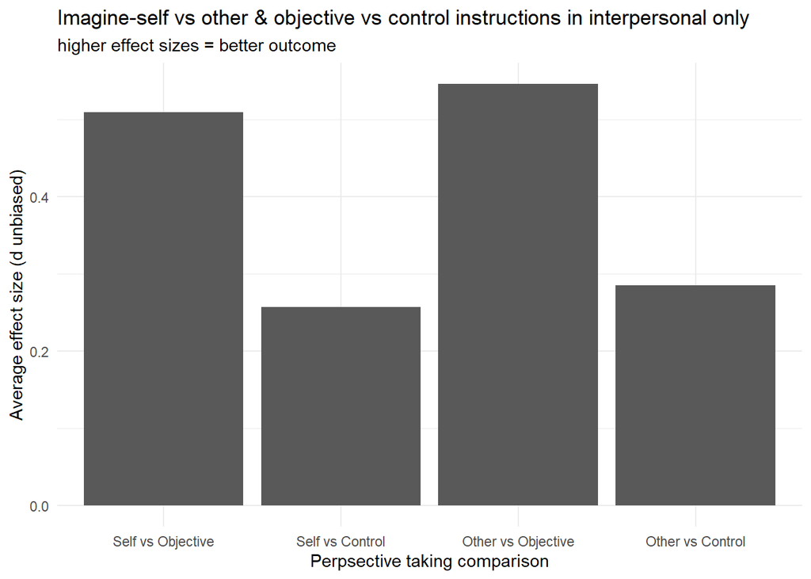

```r
emmeans_feels1 %>% ggplot(aes(x = pt_comparison, y = emmean)) +
  geom_col() +
  theme_minimal() +
  labs(title = "Imagine-self vs other & objective vs control instructions in interpersonal only",
       subtitle = "higher effect sizes = better outcome",
       x = "Perpsective taking comparison",
       y = "Average effect size (d unbiased)") +
  scale_x_discrete(labels = c('Self vs Objective','Self vs Control',
                              'Other vs Objective', 'Other vs Control'))
```

The marginal main effects indicate that all effect sizes except self v control significantly differ from 0. However, both self and other vs objective have medium to large effect sizes, and other v control has a small effect size.

### Overall I2 for model

```r
get_I2_overall(feels, feels_model)
```

```
## [1] 92.16887
```

High heterogeneity.

### I2 for levels of variance

*Left value corresponds to top sigma in Variance components output in model results (Sample_number_total). Right-most value corresponds to bottom sigma (Outcome_scale group).*

```r
get_I2_var_levels(feels, feels_model)
```

```
## [1] 69.97  6.20  4.84 11.16
```

## Moderators

### Scales of measurement

```r
feels %>%
  group_by(outcome_scale_group) %>%
  count()
```

```
## # A tibble: 6 x 2
## # Groups:   outcome_scale_group [6]
##   outcome_scale_group     n
##   <fct>               <int>
## 1 10                     66
## 2 11                     37
## 3 13                     11
## 4 14                     50
## 5 15                     19
## 6 16                      1
```

```r
feels_mod <- feels %>%
  filter(outcome_scale_group != 16) %>%
  unique() #removing this level since there is only one study in it

feels_mod$outcome_scale_group <- droplevels(feels_mod$outcome_scale_group)

#model with interaction
feels_model_mod1 <- rma.mv(dunb,
                      var_dunb,
                      mods = ~ pt_comparison*outcome_scale_group,
                      random = list(~ 1 | sample_number_total/outcomes_within_sample_var/conditions_within_sample_var),
                      data = feels_mod)

feels_model_mod1
```

```
##
## Multivariate Meta-Analysis Model (k = 183; method: REML)
##
## Variance Components:
##
##             estim    sqrt  nlvls  fixed
## sigma^2.1  0.2903  0.5388     88     no
## sigma^2.2  0.0550  0.2345    129     no
## sigma^2.3  0.0119  0.1089    177     no
##                                                                                 factor
## sigma^2.1                                                          sample_number_total
## sigma^2.2                               sample_number_total/outcomes_within_sample_var
## sigma^2.3  sample_number_total/outcomes_within_sample_var/conditions_within_sample_var
##
## Test for Residual Heterogeneity:
## QE(df = 167) = 819.6153, p-val < .0001
##
## Test of Moderators (coefficients 2:16):
## QM(df = 15) = 71.9450, p-val < .0001
##
## Model Results:
##
##                                                       estimate      se     zval
## intrcpt                                                 0.8974  0.1329   6.7544
## pt_comparisonself_v_control                            -0.3233  0.1504  -2.1499
## pt_comparisonother_v_objective                          0.0320  0.1174   0.2728
## pt_comparisonother_v_control                           -0.3156  0.1330  -2.3737
## outcome_scale_group11                                  -0.6595  0.3262  -2.0215
## outcome_scale_group13                                  -0.4075  0.3120  -1.3060
## outcome_scale_group14                                  -0.3741  0.1780  -2.1019
## outcome_scale_group15                                  -0.4405  0.2241  -1.9659
## pt_comparisonself_v_control:outcome_scale_group11       0.3554  0.3360   1.0577
## pt_comparisonother_v_objective:outcome_scale_group11    0.0804  0.3475   0.2314
## pt_comparisonother_v_control:outcome_scale_group11      0.5086  0.3592   1.4161
## pt_comparisonother_v_objective:outcome_scale_group13   -0.3452  0.4369  -0.7902
## pt_comparisonself_v_control:outcome_scale_group14       0.0791  0.2015   0.3925
## pt_comparisonother_v_objective:outcome_scale_group14   -0.0138  0.1728  -0.0798
## pt_comparisonother_v_control:outcome_scale_group14      0.0541  0.1838   0.2946
## pt_comparisonself_v_control:outcome_scale_group15      -0.3169  0.2912  -1.0882
##                                                         pval    ci.lb    ci.ub
```

[output cut: 21 more lines]

```
## outcome_scale_group11                                   *
## outcome_scale_group13
## outcome_scale_group14                                   *
## outcome_scale_group15                                   *
## pt_comparisonself_v_control:outcome_scale_group11
## pt_comparisonother_v_objective:outcome_scale_group11
## pt_comparisonother_v_control:outcome_scale_group11
## pt_comparisonother_v_objective:outcome_scale_group13
## pt_comparisonself_v_control:outcome_scale_group14
## pt_comparisonother_v_objective:outcome_scale_group14
## pt_comparisonother_v_control:outcome_scale_group14
## pt_comparisonself_v_control:outcome_scale_group15
##
## ---
## Signif. codes:  0 '***' 0.001 '**' 0.01 '*' 0.05 '.' 0.1 ' ' 1
```

Scale group 10 (Empathy) is the reference group. Dropped scale group 16 since there was only one study in it. The analysis dropped redundant comparisons that have 0 studies per cell. There were no significant interactions (so one instruction did not work better with one scale than another in comparison to intercept).

#### I2 overall

```r
get_I2_overall(feels_mod, feels_model_mod1)
```

```
## [1] 90.99717
```

#### I2 for levels of variance

*Left value corresponds to top sigma in Variance components output in model results (Sample_number_total). Right-most value corresponds to bottom sigma (Outcome_scale group).*

```r
get_I2_var_levels(feels_mod, feels_model_mod1)
```

```
## [1] 73.97 14.01  3.02
```

Most heterogeneity is explained by between-study variance, followed by between-outcomes variance.

### Target - amount of information

```r
feels_model_mod2 <- rma.mv(dunb,
                      var_dunb,
                      mods = ~ pt_comparison*target_information,
                      random = list(~ 1 | sample_number_total/outcomes_within_sample_var/conditions_within_sample_var,
                                    ~ 1 | outcome_scale_group),
                      data = feels_mod)

feels_model_mod2
```

```
##
## Multivariate Meta-Analysis Model (k = 183; method: REML)
##
## Variance Components:
##
##             estim    sqrt  nlvls  fixed
## sigma^2.1  0.3213  0.5668     88     no
## sigma^2.2  0.0298  0.1727    129     no
## sigma^2.3  0.0195  0.1396    177     no
## sigma^2.4  0.0550  0.2345      5     no
##                                                                                 factor
## sigma^2.1                                                          sample_number_total
## sigma^2.2                               sample_number_total/outcomes_within_sample_var
## sigma^2.3  sample_number_total/outcomes_within_sample_var/conditions_within_sample_var
## sigma^2.4                                                          outcome_scale_group
##
## Test for Residual Heterogeneity:
## QE(df = 172) = 972.6541, p-val < .0001
##
## Test of Moderators (coefficients 2:11):
## QM(df = 10) = 22.9730, p-val = 0.0108
##
## Model Results:
##
##                                                     estimate      se     zval
## intrcpt                                               0.1488  0.3078   0.4835
## pt_comparisonself_v_control                           0.2225  0.4318   0.5152
## pt_comparisonother_v_objective                        0.2690  0.2741   0.9815
## pt_comparisonother_v_control                         -0.0325  0.2056  -0.1582
## target_information2                                   0.3271  0.3218   1.0163
## target_information3                                   0.3397  0.2482   1.3686
## pt_comparisonself_v_control:target_information2      -0.4829  0.4494  -1.0745
## pt_comparisonother_v_objective:target_information2   -0.1979  0.2972  -0.6658
## pt_comparisonother_v_control:target_information2     -0.2306  0.2367  -0.9740
## pt_comparisonself_v_control:target_information3      -0.4907  0.4754  -1.0321
## pt_comparisonother_v_objective:target_information3   -0.2575  0.2274  -1.1323
##                                                       pval    ci.lb   ci.ub
## intrcpt                                             0.6287  -0.4545  0.7521
## pt_comparisonself_v_control                         0.6064  -0.6238  1.0687
## pt_comparisonother_v_objective                      0.3264  -0.2682  0.8062
## pt_comparisonother_v_control                        0.8743  -0.4356  0.3705
## target_information2                                 0.3095  -0.3037  0.9578
## target_information3                                 0.1711  -0.1468  0.8262
## pt_comparisonself_v_control:target_information2     0.2826  -1.3636  0.3979
## pt_comparisonother_v_objective:target_information2  0.5055  -0.7803  0.3846
## pt_comparisonother_v_control:target_information2    0.3300  -0.6946  0.2334
## pt_comparisonself_v_control:target_information3     0.3020  -1.4225  0.4412
## pt_comparisonother_v_objective:target_information3  0.2575  -0.7033  0.1883
##
## ---
## Signif. codes:  0 '***' 0.001 '**' 0.01 '*' 0.05 '.' 0.1 ' ' 1
```

None are significant. Emmeans won’t work because redundant predictors were dropped from ram.mv model.

#### I2 overall

```r
get_I2_overall(feels_mod, feels_model_mod2)
```

```
## [1] 92.55147
```

High heterogeneity - moderator did not help.

#### I2 for levels of variance

*Left value corresponds to top sigma in Variance components output in model results (Sample_number_total). Right-most value corresponds to bottom sigma (Outcome_scale group).*

```r
get_I2_var_levels(feels_mod, feels_model_mod2)
```

```
## [1] 69.86  6.49  4.24 11.96
```

Most variance explained by between-study variance, with almost 12% explained by scales of measurement.

### Target - In need/In distress target grouping (relevant to outcome category)

```r
feels_model_mod3 <- rma.mv(dunb,
                      var_dunb,
                      mods = ~ pt_comparison*target_emapthetic_need,
                      random = list(~ 1 | sample_number_total/outcomes_within_sample_var/conditions_within_sample_var,
                                    ~ 1 | outcome_scale_group),
                      data = feels_mod)

feels_model_mod3
```

```
##
## Multivariate Meta-Analysis Model (k = 183; method: REML)
##
## Variance Components:
##
##             estim    sqrt  nlvls  fixed
## sigma^2.1  0.2959  0.5440     88     no
## sigma^2.2  0.0284  0.1684    129     no
## sigma^2.3  0.0235  0.1532    177     no
## sigma^2.4  0.0596  0.2441      5     no
##                                                                                 factor
## sigma^2.1                                                          sample_number_total
## sigma^2.2                               sample_number_total/outcomes_within_sample_var
## sigma^2.3  sample_number_total/outcomes_within_sample_var/conditions_within_sample_var
## sigma^2.4                                                          outcome_scale_group
##
## Test for Residual Heterogeneity:
## QE(df = 175) = 972.2309, p-val < .0001
##
## Test of Moderators (coefficients 2:8):
## QM(df = 7) = 20.8189, p-val = 0.0040
##
## Model Results:
##
##                                                         estimate      se
## intrcpt                                                   0.4511  0.2054
## pt_comparisonself_v_control                              -0.1497  0.2023
## pt_comparisonother_v_objective                            0.0182  0.1616
## pt_comparisonother_v_control                             -0.2919  0.1752
## target_emapthetic_need2                                   0.0733  0.2238
## pt_comparisonself_v_control:target_emapthetic_need2      -0.1639  0.2450
## pt_comparisonother_v_objective:target_emapthetic_need2    0.0086  0.2055
## pt_comparisonother_v_control:target_emapthetic_need2      0.1482  0.2194
##                                                            zval    pval
## intrcpt                                                  2.1965  0.0281
## pt_comparisonself_v_control                             -0.7397  0.4595
## pt_comparisonother_v_objective                           0.1123  0.9106
## pt_comparisonother_v_control                            -1.6659  0.0957
## target_emapthetic_need2                                  0.3274  0.7434
## pt_comparisonself_v_control:target_emapthetic_need2     -0.6690  0.5035
## pt_comparisonother_v_objective:target_emapthetic_need2   0.0418  0.9667
## pt_comparisonother_v_control:target_emapthetic_need2     0.6756  0.4993
##                                                           ci.lb   ci.ub
## intrcpt                                                  0.0486  0.8536  *
## pt_comparisonself_v_control                             -0.5462  0.2469
## pt_comparisonother_v_objective                          -0.2986  0.3349
## pt_comparisonother_v_control                            -0.6352  0.0515  .
## target_emapthetic_need2                                 -0.3654  0.5119
## pt_comparisonself_v_control:target_emapthetic_need2     -0.6440  0.3163
## pt_comparisonother_v_objective:target_emapthetic_need2  -0.3942  0.4113
## pt_comparisonother_v_control:target_emapthetic_need2    -0.2817  0.5781
##
## ---
## Signif. codes:  0 '***' 0.001 '**' 0.01 '*' 0.05 '.' 0.1 ' ' 1
```

The intercept is significantly different from 0. The difference between other v control and intercept is marginal. There are no interactions.

#### Marginal main effects

```r
qdrq_feels3 <- qdrg(object = feels_model_mod3, data = feels_mod)

emmeans_feels3 <- summary(emmeans(qdrq_feels3, "pt_comparison", "target_emapthetic_need"))
emmeans_feels3
```

```
## target_emapthetic_need = 1:
##  pt_comparison     emmean    SE  df asymp.LCL asymp.UCL
##  self_v_objective   0.451 0.205 Inf    0.0486     0.854
##  self_v_control     0.301 0.184 Inf   -0.0589     0.662
##  other_v_objective  0.469 0.157 Inf    0.1619     0.777
##  other_v_control    0.159 0.157 Inf   -0.1492     0.468
##
## target_emapthetic_need = 2:
##  pt_comparison     emmean    SE  df asymp.LCL asymp.UCL
##  self_v_objective   0.524 0.180 Inf    0.1711     0.878
##  self_v_control     0.211 0.173 Inf   -0.1275     0.549
##  other_v_objective  0.551 0.159 Inf    0.2389     0.863
##  other_v_control    0.381 0.160 Inf    0.0663     0.695
##
## Confidence level used: 0.95
```

Self and other vs objective still are different from 0 when the target is empathetic. Self and other vs control are not different from 0 when the target is empathetic. When the target is not empathetic, the only condition that does not differ from 0 is self vs control.

#### I2 overall

```r
get_I2_overall(feels_mod, feels_model_mod3)
```

```
## [1] 92.16268
```

High heterogeneity

#### I2 for levels of variance

*Left value corresponds to top sigma in Variance components output in model results (Sample_number_total). Right-most value corresponds to bottom sigma (Outcome_scale group).*

```r
get_I2_var_levels(feels_mod, feels_model_mod3)
```

```
## [1] 66.96  6.42  5.31 13.48
```

Most heterogeneity explained by between-studies variance, with over 13% by scales of measurement.

### Sample size

```r
feels_model_mod4 <- rma.mv(dunb,
                      var_dunb,
                      mods = ~ pt_comparison*n_overall,
                      random = list(~ 1 | sample_number_total/outcomes_within_sample_var/conditions_within_sample_var,
                                    ~ 1 | outcome_scale_group),
                      data = feels_mod)

feels_model_mod4
```

```
##
## Multivariate Meta-Analysis Model (k = 183; method: REML)
##
## Variance Components:
##
##             estim    sqrt  nlvls  fixed
## sigma^2.1  0.2894  0.5380     88     no
## sigma^2.2  0.0275  0.1657    129     no
## sigma^2.3  0.0246  0.1569    177     no
## sigma^2.4  0.0568  0.2382      5     no
##                                                                                 factor
## sigma^2.1                                                          sample_number_total
## sigma^2.2                               sample_number_total/outcomes_within_sample_var
## sigma^2.3  sample_number_total/outcomes_within_sample_var/conditions_within_sample_var
## sigma^2.4                                                          outcome_scale_group
##
## Test for Residual Heterogeneity:
## QE(df = 175) = 946.5303, p-val < .0001
##
## Test of Moderators (coefficients 2:8):
## QM(df = 7) = 19.8229, p-val = 0.0060
##
## Model Results:
##
##                                           estimate      se     zval    pval
## intrcpt                                     0.5423  0.2131   2.5450  0.0109
## pt_comparisonself_v_control                -0.1961  0.2388  -0.8212  0.4115
## pt_comparisonother_v_objective              0.0879  0.1702   0.5164  0.6056
## pt_comparisonother_v_control               -0.1168  0.1998  -0.5844  0.5589
## n_overall                                  -0.0008  0.0009  -0.8498  0.3955
## pt_comparisonself_v_control:n_overall      -0.0002  0.0008  -0.2306  0.8176
## pt_comparisonother_v_objective:n_overall   -0.0002  0.0007  -0.3390  0.7346
## pt_comparisonother_v_control:n_overall     -0.0006  0.0008  -0.7300  0.4654
##                                             ci.lb   ci.ub
## intrcpt                                    0.1247  0.9600  *
## pt_comparisonself_v_control               -0.6640  0.2719
## pt_comparisonother_v_objective            -0.2457  0.4215
## pt_comparisonother_v_control              -0.5083  0.2748
## n_overall                                 -0.0025  0.0010
## pt_comparisonself_v_control:n_overall     -0.0018  0.0015
## pt_comparisonother_v_objective:n_overall  -0.0017  0.0012
## pt_comparisonother_v_control:n_overall    -0.0022  0.0010
##
## ---
## Signif. codes:  0 '***' 0.001 '**' 0.01 '*' 0.05 '.' 0.1 ' ' 1
```

Intercept different from 0. No interaction with sample size.

#### I2 overall

```r
get_I2_overall(feels_mod, feels_model_mod4)
```

```
## [1] 91.96742
```

#### I2 for levels of variance

*Left value corresponds to top sigma in Variance components output in model results (Sample_number_total). Right-most value corresponds to bottom sigma (Outcome_scale group).*

```r
get_I2_var_levels(feels_mod, feels_model_mod4)
```

```
## [1] 66.84  6.34  5.69 13.11
```